# CustomerComplaintImplementation

None

## Author Information

- **Name**: Tejaswini Naidu
- **ID**: tn152
- **Coursework**: 2

## Notebook Overview

This Jupyter Notebook is designed to address two primary research questions:

1. **How can consumer complaint narratives assist in the accurate classification of complaints for different financial products offered by financial institutions?**
2. **How can different classification methods enhance consumer experience through machine learning?**

Various machine learning models including Naive Bayes, Decision Trees, Neural Networks, Random Forests, and Generalized Linear Models (GLMs) are implemented to classify consumer complaints into relevant financial product categories. The notebook also delves into feature importance analysis to interpret the contribution of consumer complaint narratives to classification accuracy and consumer experience.

1. Introduction
   - Our Research Questions
   - Objectives and Contributions
2. Literature Review
   - Introduction
   - Conclusion
3. Proposed Scientific Methodology and Design
   - Introduction
   - Business Understanding
   - Data Understanding
   - Data Preparation
     - Data Filtering
     - Balancing the Dataset
   - Analysis/Modelling
     - Decision Model
       - Data Extraction
       - Data Preprocessing and Feature Transformation
       - Dimension Reduction
       - Selected Final Features
   - Evaluation or Validation
     - Naive Bayes
     - Decision Trees
     - Neural Nets
     - Random Forest
     - Generalized Linear Model
     - Overall Performances
     - Observations on GLM Feature Importance
     - Leveraging ML Models for Consumer Complaint Classification and Experience Enhancement
     - Unit Testing
4. Conclusion
5. Future Work
6. References
7. Appendices
   - Libraries
   - Glossary

# 1. Introduction:

In our day-to-day interactions with financial institutions, ranging from simple checking accounts to more complex financial products like loans, the quality of service provided forms the foundation of our relationship with them. This quality isn't just a temporary factor; it's a crucial element that shapes our satisfaction, loyalty, and overall engagement. With this in mind, this paper embarks on an intriguing journey into the world of [Consumer Financial Protection Bureau (CFPB) complaints](https://www.consumerfinance.gov/data-research/) within the United States. Our goal is to explore the intricacies of these complaints and uncover insights that could reshape the landscape of customer experiences.

#### **Journeying through the Landscape:**

From January 2021 up to the present day, financial institutions have been inundated with hundreds of thousands of consumer complaints. The sheer volume of these concerns underscores the need to uncover hidden patterns within this extensive dataset. However, our aim goes beyond just statistical analysis; we're on a mission to unlock meaningful insights that can help us understand both current trends and emerging patterns, ultimately guiding smart decision-making.

#### **Strategically Allocating Resources:**

With the power of predictive insights at our disposal, financial institutions can shift from reacting to proactively managing complaints. The ability to anticipate upcoming trends in complaints empowers institutions to allocate resources strategically. This, in turn, leads to the efficient resolution of complaints, enhancing customer satisfaction and cultivating long-lasting loyalty.

#### **Measuring the Pulse of Consumer Satisfaction:**

Within the tapestry of consumer complaints lies a measure of customer satisfaction. The path of complaint resolution over time resembles a heartbeat monitor, revealing the rhythm of customer experiences. Our exploration into these grievances offers a deep understanding of how consumers perceive financial products and services. This multi-dimensional view acts as a compass for identifying market challenges and shaping strategies for better customer outcomes.

#### **Unveiling Insights for Transformation:**

Our journey doesn't stop at the surface. We're committed to diving deeper, exploring the realms where transformative insights lie. These consumer complaints are more than just stories; they're candid reflections of customer journeys. Armed with this treasure trove of information, financial institutions gain the power to refine customer service strategies, reshape policies, and transform practices in alignment with customer needs and expectations.

#### **Insights Straight from the Frontlines:**

These consumer complaints aren't mere anecdotes; they offer powerful insights into the intricate challenges customers face while navigating financial products and services. These stories serve as catalysts for positive change, guiding institutions to be more responsive and adaptable. By harnessing the inherent power of these insights, institutions can proactively address issues, anticipate future concerns, and design solutions that deeply resonate with customers.

#### **Harnessing the Power of Predictive Analytics:**

As our research advances, it shifts from passive observation to active engagement with predictive analytics. Armed with extensive datasets of recent customer complaints, we weave them into the fabric of probabilistic models. This transformative process is enabled by a blend of natural language processing (NLP) techniques in Python and machine learning methods. These techniques empower us to uncover patterns, gain predictive insights, and make strategic decisions.

#### **Empowering Automated Support through NLP:**

Continuing on this innovative journey, we incorporate NLP techniques to empower automated support systems. By analyzing customer complaint texts, we uncover keywords that play a pivotal role in accurate product classification. This enrichment empowers automated systems to offer targeted assistance that aligns seamlessly with customer needs.

#### **Navigating the Research Landscape:**

As you journey through this research report, each section offers a unique perspective into the realm of consumer complaints. The Literature Review sets the stage, followed by a deep dive into methodology and architectural design. The spotlight then shifts to the development, design, and implementation of models, each step revealing new discoveries. With models in action, results come to light, bridging the gap between data and actionable insights. As the report concludes, it opens doors to future exploration—uncharted territories of research and innovation.

## 1.1 Our Research Questions

**RQ1: How Can Consumer Complaint Narratives Assist in the Accurate Classification of Complaints for Different Financial Products Offered by Financial Institutions?**

This exploration aims to comprehend the role of *consumer complaint narratives* in effectively categorizing complaints into relevant financial product categories provided by various financial institutions. Analyzing these narratives seeks to uncover their contribution to accurate classification.

**RQ2: How Can Different Classification Methods Enhance Consumer Experience Through Machine Learning?**

This question delves into the utility of diverse classification methods, *using machine learning techniques* to enrich consumer experiences. We examine whether varied classification approaches lead to improved consumer satisfaction. This involves a comparative study to recommend optimal strategies for refining the overall consumer journey.

Constructing models with classifier techniques can compromise inherent data information. While text classifier models developed solely based on complaint features and perceptual features might underperform, adopting a holistic approach through different classifier models may yield more favorable results. This comprehensive approach illuminates multiple dimensions of consumer complaint narratives, potentially offering valuable insights.

Operationalizing this approach within an automated response system, like a chatbot, aims to elevate user interaction experiences. Such **technology-human collaboration, coupled with the expertise of the CFPB team**, can enhance consumer experiences by addressing issues related to **delays, misrouting, errors, and unjust practices** in seeking services from financial institutions.

This collaboration holds the promise of delivering effective analyses of consumer complaint narratives. The proposed research centers on classifying consumer complaint narratives into respective products using various machine learning models, such as **Naïve Bayes, Decision Tree, Generalised Linear Model, Random Forest, and Deep Learning model**s. Through these efforts, we aspire to **enhance consumer experience and operational efficiency** in the realm of financial institution services.

## 1.2 Objectives and Contributions

- Feature Extraction and selection of feature sets.
- Implementation of multi text classifiers (e.g. Naïve Bayes, GLM, RF, DT, Deep Learning) and comparing the performance.

The main purpose is to analyze the consumer complaint narratives by CFPB and gain insights about improving customer service from both the financial institution's perspective and the customer's perspective. To achieve this goal, we:

- Build and evaluate individual classifier models.
- Compare the performance of these models, including deep learning approaches.

The following section outlines the literature review of recent researches that provided insights and ideas for identifying the scope of our research. Subsequently, the methods and their specifications are discussed in the next section, which includes a detailed explanation of the methodology, steps for data pre-processing, building various models, and evaluating their effectiveness. Finally, the research concludes with the findings of the model experiments and potential avenues for future work.

# 2. Literature Review

## 2.1 Introduction

This research delves into the landscape of prior studies closely related to consumer complaint analysis. Its primary focus is to illuminate the insights gleaned from previous research, exploring how financial organizations have harnessed the potential of the consumer complaint database. These studies decipher trends, formulate hypotheses, and gauge the impact of financial institutions' responses on overall consumer satisfaction. Credible sources such as journals, web articles, news reports, IEEE papers, and books constitute the foundation of this literature exploration.

The inception of the Consumer Financial Protection Bureau (CFPB) in 2011 was marked by [four missions](https://files.consumerfinance.gov/f/reports/CFPB_Financial_Report_FY_2011.pdf):

- ensuring credit access through law enforcement,
- consumer education,
- safeguarding service members' financial interests, and
- protecting the interests of older Americans.

Mandated by the Dodd-Frank Wall Street Reform and Consumer Protection Act, CFPB acts as a conduit for consumers to voice their concerns within the financial sector. The database encapsulates an array of consumer complaints spanning credit cards, mortgages, student loans, auto loans, credit reports, consumer loans, and debt collection. Accessible to the public on the [CFPB website](https://www.consumerfinance.gov/data-research/), this repository beckons financial institutions, data analysts, scientists, and academicians alike to delve into its depths. *The aim: to decipher insights that reshape institutional policies, regulations, and service quality, thereby nurturing customer experiences.*

**[Ayres et al. (2013):](https://ir.lawnet.fordham.edu/jcfl/vol19/iss2/2/)** This early analysis scrutinized the CFPB consumer complaint database at an institutional and demographic level. By dissecting data in three distinct ways—company-wise, dispute percentages, and timeliness of responses—the study spotlighted significant variances. Notably, big financial services providers faced a higher likelihood of disputes. Furthermore, Ayres et al. examined the interplay between demographic information and complaint volume, revealing intriguing correlations.

**[Littwin (2015):](https://papers.ssrn.com/sol3/papers.cfm?abstract_id=2711399)** Littwin's analysis cast a different light on the CFPB database, emphasizing the pivotal role of government financial agencies. The research underscored three key benefits: dispute resolution, regulatory oversight, and fostering goodwill for government financial institutions. Regression-based analyses underscored the CFPB's success in dispute resolution and regulatory activities.

While Ayres et al. and Littwin contributed valuable insights, they largely bypassed the narrative aspect of consumer complaints. However, the growing volume of complaint narratives warrants a more comprehensive approach. Text mining emerges as a potent solution, extracting knowledge from unstructured text documents [Aggarwal and Zhai, 2012](https://link.springer.com/chapter/10.1007/978-1-4614-3223-4_6). Prominent approaches include Latent Semantic Analysis (LSA) and Latent Dirichlet Allocation (LDA). While LSA clusters based on predefined groups, LDA models extract groups directly from the texts.

**[Kaveh et al. (2016):](https://arxiv.org/ftp/arxiv/papers/1807/1807.07468.pdf)** Kaveh's LDA-based approach categorizes complaints, overcoming limitations of predefined annotations. This approach illuminates trends and the effectiveness of regulations.

**[Tom Sabo (2017):](https://www.semanticscholar.org/paper/Applying-Text-Analytics-and-Machine-Learning-to-Sabo/400cb1e5ecbd03b639c613821a4f8d9192f32aeb)** Tom Sabo extended this horizon by harnessing SAS contextual analytics software, employing machine learning and sentiment analysis to predict outcomes. This holistic analysis showcases the versatility of the approach, applicable to diverse sectors.

In the quest for deeper insights, this chapter underscores the significance of narrative analysis and the multifaceted tools at our disposal. Each study contributes a unique dimension to the collective understanding of consumer complaint narratives, presenting avenues for holistic analysis and strategic improvements.

## 2.2 Conclusion of Literature Review

The comprehensive literature review reveals a series of distinct approaches in analyzing the CFPB consumer complaint database. Early analyses primarily centered around financial institutions and government agencies, while subsequent studies ventured into harnessing the potential of consumer complaint narratives using techniques like LSA and LDA. The most recent endeavor involved employing machine learning techniques and statistical analysis software to predict monetary benefits based on consumer complaints, underscoring the evolving landscape of analysis methodologies.

Amidst this backdrop, an intriguing scope emerges—an opportunity to conduct a nuanced **'Text Analysis of Consumer Complaint Narratives.'** The goal is to employ diverse machine learning techniques to categorize complaints by their relevant products offered by financial institutions. By comparing results in terms of accuracy and time efficiency, the ultimate objective is to enhance the consumer experience.

Notably, this study marks the inaugural exploration into utilizing machine learning for dissecting consumer complaint narratives within the CFPB datasets. Machine learning proves instrumental in classifying structured and unstructured narratives into an array of topics, shedding light on the underlying meanings embedded within the text. While a human endeavor would be infeasible due to the sheer volume, our approach leverages models built on multiple classification techniques.

**Naïve Bayes, Generalized Linear Model, Decision Tree, Random Forest,** and **Deep Learning** techniques form the backbone of our exploration. A meticulous comparison of these techniques enables us to glean insights into their performance and effectiveness. This analysis further extends to revealing the evolving trend of consumer complaints pertaining to specific products offered by financial institutions. Moreover, it offers a lens to assess the efficacy of CFPB's policies designed to address these grievances.

In the subsequent sections, we delve into the proposed utilization of machine learning for text analysis of the CFPB consumer complaint database. Detailed discussions revolve around the outcomes generated by the diverse classifier models we've constructed. As we embark on this journey, we aim to uncover valuable insights that promise to reshape the landscape of consumer experiences and contribute to the refinement of financial institutions' policies and practices.

# 3 Proposed Scientific Methodology and Design

## 3.1 Introduction

[figure not shown]

This research aims to utilize consumer complaint narratives and classify them into respective products defined by the CFPB dataset using various data mining classification techniques. The chosen methodology for achieving this goal is the CRISP-DM methodology (Cross Industry Process for Data Mining), known for its structured approach and practical effectiveness. CRISP-DM encompasses several stages, as depicted in above Figure.

[figure not shown]

The above steps may be intermixed based on the design architecture, but they should be followed in the appropriate order to ensure the model's accuracy and computational efficiency.

## 3.2 Business Understanding

The role of the business is pivotal in the model-building process. During this stage, we comprehended the project requirements and objectives, evaluating their feasibility based on the research question at hand. We identified key factors that were missing from the project scope. Our primary aim was to classify consumer complaint narratives into their respective products or services provided by diverse financial institutions. We rigorously assessed the project's details and timeline for applying various mining techniques and comparing the outcomes.

## 3.3 Data Understanding

The Consumer Complaint Database is a repository of complaints received by the Consumer Finance Protection Bureau (CFPB) related to a wide range of consumer financial products and services offered by banks and financial institutions across the United States of America. This dataset, intended for public access and use, includes attributes that uniquely describe and identify each complaint. Our analysis focused on a collection of 19,26,112 complaints gathered from 01 January 2021 to 06 July 2023. These complaints comprise 18 attributes, including submission date, product, issue description, company, and more.

Of particular interest in this research is the "Consumer Complaint Narrative" field, which contains descriptions provided by consumers about their experiences. Notably, this field may not be populated for all records as it depends on the consumer's choice to share. To maintain the integrity of our analysis, we selected records with available consumer complaint narratives. This led to a total of 5,84,284 records. While some narratives might be repetitive, we opted to use the data as is for our text mining analysis.

[figure not shown]

Column 2 (Product) and Column 5 (Consumer_Complaint_Narratives) are of primary concern in this research. The "Product" column encompasses the various services offered by financial institutions, such as credit, debit, mortgage, and student loans. Other columns containing information about states, sub-products, timely responses, etc., are also briefly examined and explored in Coursework 1 of *CustomerComplaintExploration.ipynb*. **Coursework 1** helped in visualizing the data distribution through graphical representations aids in understanding the dataset comprehensively.The remaining columns in the dataset are not pertinent to the scope of this research and therefore aren't discussed in detail in this Coursework 2 and has been already explored in CW1.

## 3.3 Data Preparation

In this step, our focus shifts to preparing the raw data files for utilization in the model, employing machine learning implementation. Effective data pre-processing plays a pivotal role in enhancing the model's performance.

The data preparation process involves various sub-steps, encompassing:

1. Handling NULL values
2. Removing unnecessary data
3. Balancing the data through under-sampling and over-sampling techniques

The primary objective of these sub-steps is to create a cleaned and balanced dataset, optimized for utilization in machine learning model training. The upcoming sections provide insights into the initial steps undertaken during data preprocessing, including data segregation and balancing of categories through under-sampling and over-sampling.

### 3.3.1 Data Filtering Only with Top 5 Products

In this step, we aim to streamline our data preparation process by focusing solely on the "Consumer_Complaint_Narratives" and "Product" columns. Given the highly imbalanced nature of the dataset, we've decided to narrow our focus to the top 5 product categories for a more manageable and balanced dataset. This approach helps us mitigate the challenges posed by data imbalance.

To achieve this, we follow these steps:

1. **Selection of Relevant Columns**: We extract the "Consumer_Complaint_Narratives" and "Product" columns from the dataset, as they are our primary areas of interest.
2. **Balancing the Dataset**: Since the dataset exhibits significant class imbalance, we opt for downsampling. This entails reducing the number of entries in the majority class categories to match the minority class categories. This balanced dataset facilitates more effective model training and evaluation.

Our approach is designed to enhance the model's performance while working with a manageable dataset. By focusing on the narratives and product categories most relevant to our analysis, we optimize the data for machine learning implementation and ensure that the model is trained on a balanced representation of categories.

Hence from Exploration of Data from Coursework 1 we have below distributions of Products:

```python
import pandas as pd
pd.set_option('display.max_columns', None)
pd.set_option('display.max_rows', None)

from CustomerComplaintExploration import *

# Step 1: Define the preprocessed data file path from Coursework 1 and load it
full_dataset_file_path = 'input_data/customer_complaints_full.csv'
# OR
# full_dataset_file_path = 'input_data/customer_complaints_sample.csv'
inDF = pd.read_csv(full_dataset_file_path)


# Step 2: Now clean the dataset with the function from coursework 1
processDF = preprocess_data(inDF)

# Plot Products distribution
explore_product(processDF)
```

```
Preprocessing completed in 3.84 seconds.
```

[interactive chart not shown]

```python
# inDF.sample(frac=0.02, random_state=42).to_csv('input_data/customer_complaints_sample.csv')
```

So from above figure, going forward lets use data which shows product from below list

1. **Credit reporting, credit repair services, or other personal consumer reports** (aka **Credit reporting, repair or reports** from figure)
2. **Debt Collection**
3. **Credit or prepaid card**
4. **Checking or savings account**
5. **Mortgage**

```python
# Limiting our dataset to only above top 5 products
# Step 1: Identify the top 5 products
top_products = processDF['Product'].value_counts().head(5).index.tolist()
print(f"Top Products: {top_products}")

# Step 2: Create a new dataset with only the top 5 products
filtered_df = processDF[processDF['Product'].isin(top_products)]

# Plot Products distribution
explore_product(filtered_df)
```

```
Top Products: ['Credit reporting, credit repair services, or other personal consumer reports', 'Debt collection', 'Credit card or prepaid card', 'Checking or savings account', 'Mortgage']
```

[interactive chart not shown]

Above figure shows **Mortgage** with the lowest count. Lets calculate the ratio of complaint counts for each product category relative to **Mortgage** to understand the proportionality of complaints across categories.

```python
# Step 3: Calculate the ratio of each product category to "Mortgage"
mortgage_count = filtered_df[filtered_df['Product'] == 'Mortgage'].shape[0]
filtered_df['Ratio to Mortgage'] = filtered_df.groupby('Product')['Product'].transform('count') / mortgage_count

# Display the DataFrame with the ratios
filtered_df[['Product', 'Ratio to Mortgage']].drop_duplicates()
```

|  | Product | Ratio to Mortgage |
| --- | --- | --- |
| 547105 | Debt collection | 2.330060 |
| 1071087 | Credit reporting, credit repair services, or o... | 10.981300 |
| 1483203 | Credit card or prepaid card | 1.553403 |
| 1071077 | Mortgage | 1.000000 |
| 547256 | Checking or savings account | 1.379301 |

After analyzing the dataset and considering the top 5 product categories, it becomes evident that there are significant variations in the number of complaints received for each product category. When compared to the "Mortgage" category, we observe the following ratios of complaints for other product categories:

1. **Debt collection** has approximately 2.33 times more complaints than the "Mortgage" category.
2. **Credit reporting, repair or reports** receives nearly 11 times more complaints than "Mortgage."
3. **Credit or prepaid card** has around 1.55 times more complaints compared to "Mortgage."
4. "Mortgage" is used as the reference category with a ratio of 1. This is expected since we are comparing other categories to it.
5. **Checking or savings account** receives approximately 1.38 times more complaints than "Mortgage."

#### Balancing the Dataset is required

In our analysis, we observed that two product categories, **Credit reporting, repair or reports** and **Debt collection**, have significantly higher complaint counts compared to the remaining three categories: **Credit or prepaid card**, **Checking or savings account**, and **Mortgage**. To achieve a more balanced dataset and avoid potential biases in our analysis, we decided to undersample the **Credit reporting** and **Debt collection** categories.

##### 1. Undersampling **Credit Reporting**:

The **Credit reporting** category had an exceptionally high complaint count, approximately 10.98 times that of the "Mortgage" category. By undersampling this category, we aim to reduce its contribution to the analysis, making it more comparable to the other three categories. While it won't be a perfect match, this approach allows us to mitigate the skewness caused by the overwhelming number of **Credit reporting** complaints.

##### 2. Undersampling **Debt Collection**:

Similar to **Credit reporting**, the **Debt collection** category had a significantly higher complaint count, approximately 2.33 times that of "Mortgage." Undersampling this category brings it closer in terms of complaint counts to the remaining three categories, reducing the potential bias it may introduce into the analysis.

##### 3. Keeping the Other Three Categories As Identicals:

Conversely, we decided to keep the complaint counts for the other three categories (**Credit or prepaid card**, **Checking or savings account**, and **Mortgage**) unchanged. These categories had relatively fewer complaints compared to **Credit reporting** and **Debt collection**, but the differences were not as extreme. Maintaining the original counts for these categories allows us to analyze them in their natural distribution, as the differences in counts are not as significant as the two aforementioned categories.

This approach aims to strike a balance between fairness in the analysis and the practicality of handling imbalanced data. It enables us to explore insights from a dataset that better represents the distribution of complaints across the selected product categories.

Certainly, here's the explanation in Jupyter Notebook markdown format:

#### How to balance the dataset now with downsampling in Code

1. **Calculate Average Count:** Compute the average count of complaints within the three selected categories (which shows lower counts in top 5). This average count will serve as the target count for undersampling the other two high count categories.
2. **Undersample Specific Categories:** For each category you want to balance (e.g., 'Credit reporting' and 'Debt collection'), select all the complaints within that category. Undersample the category by randomly selecting a fraction of the complaints to match the average count calculated earlier.
3. **Combine Undersampled Data:** Merge the undersampled complaints from each category into a new DataFrame.
4. **Combine with Unchanged Categories:** Combine the undersampled top products with the unchanged complaints from the initial subset.

```python
def balance_dataset(df):
    """
    Balances the dataset by undersampling 'Credit reporting' and 'Debt collection' to match the average count
    of 'Credit card or prepaid card', 'Checking or savings account', and 'Mortgage'.

    Args:
        df (pd.DataFrame): The input DataFrame containing the dataset.

    Returns:
        pd.DataFrame: The balanced dataset.
    """

    # Filter the DataFrame for the top 5 products
    temp_df = df[df['Product'].isin(['Credit card or prepaid card', 'Checking or savings account', 'Mortgage'])]

    # Calculate the average count of the above three categories
    average_count = temp_df.groupby('Product').size().mean()

    # Determine the desired undersampling ratio for Credit reporting and Debt collection
    # 1. Undersample Credit reporting
    df_credit_reporting = df[df['Product'] == 'Credit reporting, credit repair services, or other personal consumer reports']
    undersampled_credit_reporting = df_credit_reporting.sample(frac=average_count / len(df_credit_reporting),
                                                           random_state=42)

    # 2. Undersample Debt collection
    df_debt_collection = df[df['Product'] == 'Debt collection']
    undersampled_debt_collection = df_debt_collection.sample(frac=average_count / len(df_debt_collection),
                                                         random_state=42)

    # Combine the undersampled data
    undersampled_df_top = pd.concat([undersampled_credit_reporting, undersampled_debt_collection])

    # Combine the undersampled top products with the unchanged other categories
    new_df = pd.concat([undersampled_df_top, temp_df])

    # Plot Products distribution
    explore_product(new_df)

    return new_df

balanced_df = balance_dataset(filtered_df)
```

[interactive chart not shown]

```python
import plotly.express as px
from plotly.subplots import make_subplots

# Create a bar plot function
def plot_product_distribution(df, title, yaxis_title):
    data = df['Product'].value_counts()
    data = data.sort_values(ascending=False)

    fig = px.bar(data, x=data.index, y=data.values, color=data.index,
                 labels={'x': 'Product', 'y': 'Count', 'color': 'Product'},
                 title=title)

    fig.update_traces(texttemplate='%{y}', textposition='outside',
                      textfont_size=8)

    fig.add_annotation(x=0.5, y=1.1,
                       text="Total Complaints: " + str(data.sum()),
                       showarrow=False,
                       font=dict(size=12, color="black"),
                       xref="paper",
                       yref="paper")

    fig.update_xaxes(showticklabels=False)
    # replace 'index' with 'Product' on x-axis
    fig.update_layout(xaxis_title="Product", yaxis_title=yaxis_title)

    return fig

# Create subplots
fig = make_subplots(rows=1, cols=2, shared_yaxes=True, horizontal_spacing=0.1)

# Plot Product distribution for filtered_df
fig_filtered = plot_product_distribution(filtered_df, 'Product By Complaint Volume (Original)',
                                          'Count (Original)')
fig.update_layout(showlegend=False)
for trace in fig_filtered.data:
    fig.add_trace(trace, row=1, col=1)

# Plot Product distribution for balanced_df
fig_balanced = plot_product_distribution(balanced_df, 'Product By Complaint Volume (Balanced)',
                                         'Count (Balanced)')
fig.update_layout(showlegend=False)
for trace in fig_balanced.data:
    fig.add_trace(trace, row=1, col=2)

# Update layout
fig.update_layout(height=500, width=950,
                  title_text="Product Distribution Comparison (Before and After Balancing/Downsampling)")
fig.show()
```

[interactive chart not shown]

**Now the dataframe looks almost balanced.**

## 3.4 Analysis/Modelling

In this upcoming stage, we will proceed with the balanced dataset prepared earlier, and we will apply predictive modeling techniques. The dataset will be split into training and testing sets, allocating 75% for training and reserving 25% for testing purposes. Our initial focus will be on constructing and evaluating the Naive Bayes model. This model will be assessed based on its performance, accuracy, classification errors, and the time required for training.

Furthermore, we will explore additional classifier models such as Decision Tree, Random Forest, Gradient Boosted Tree, Fast Large Margins, General Linear Model, Support Vector Machine, and Deep Learning. Each of these models will undergo fine-tuning with appropriate parameters to optimize their performance on our dataset. Through this rigorous comparison of results, we will aim to gain valuable insights into the effectiveness of each model for our specific problem.

In addition to model evaluation, we will also pay attention to feature engineering and data preprocessing to enhance the overall performance of our predictive models.

Certainly, our upcoming model analysis might play a crucial role in addressing the research questions we have posed:

**RQ1: How Can Consumer Complaint Narratives Assist in the Accurate Classification of Complaints for Different Financial Products Offered by Financial Institutions?**

Through the model analysis, we aim to leverage consumer complaint narratives to accurately classify complaints into different financial product categories offered by financial institutions. By implementing various machine learning techniques and assessing their performance, we intend to demonstrate how effectively these narratives can contribute to precise complaint classification.

**RQ2: How Can Different Classification Methods Enhance Consumer Experience Through Machine Learning?**

Our exploration of different classification methods in this analysis serves the purpose of enhancing the consumer experience through machine learning. By comparing the results of various classifiers, we aim to identify which methods are most effective in improving the accuracy of complaint categorization. This knowledge will help financial institutions streamline their complaint handling processes, potentially resulting in better customer service and an overall enhanced consumer experience.

In summary, our model analysis will shed light on the potential of consumer complaint narratives in accurate classification and demonstrate how different classification methods can contribute to an improved consumer experience through machine learning.

### 3.4.1 Decision Model

[figure not shown]

#### 3.4.1.a Data Extraction

We have already completed data extraction stage:

#### 3.4.1.b Data Preprocessing and Feature Transformation

##### 1. Text Data Preprocessing Steps

To illustrate these tasks, we provide an example below, demonstrating how a sample document will be processed at each step:

[output not shown]

`Purpose of Stemming in Text Analysis:` The purpose of stemming in text analysis is to simplify and standardize text by reducing words to their base or root form. Stemming helps in handling variations of words more efficiently. For example, words like "protect," "protection," and "protecting" are stemmed to their base form, which is "protect." This step is crucial for improving text classification analysis by focusing on the core meaning of words rather than considering multiple variations of the same word.

`Benefits of Stemming:`

1. **Reducing Variations:** Stemming reduces words to their base form, eliminating unnecessary variations. This simplification makes it easier to analyze text data.
2. **Resource Efficiency:** Text analysis algorithms can be resource-intensive when dealing with numerous word forms. Stemming helps in conserving computational resources by treating variations as the same word.
3. **Avoiding Confusion:** Stemming reduces ambiguity and confusion in text mining algorithms. It ensures that different forms of the same word are treated as identical, leading to more accurate and consistent results.

Here, `The Porter Stemmer` is a widely used algorithm for stemming, which is the process of reducing words to their root or base form. It was developed by Martin F. Porter in 1980 and is one of the most well-known stemming algorithms. The Porter Stemmer algorithm works by removing common suffixes from words to obtain their root form. This can help in treating different forms of a word as the same, which is useful in natural language processing tasks like text analysis and information retrieval.

For example, the Porter Stemmer would convert words like "jumps," "jumping," and "jumped" to their common root form "jump."

More Information: To delve deeper into the details of the Porter Stemmer algorithm, you can refer to the [original paper by Martin F. Porter](https://tartarus.org/martin/PorterStemmer/def.txt) where he explains the algorithm and provides examples of its application.

```python
import re
from nltk.stem import PorterStemmer
from nltk.corpus import stopwords

def text_transformation(original_doc):
    """
    Apply text transformation tasks to the original document.

    Args:
        original_doc (str): The original unaltered document text.

    Returns:
        list of str: A list of transformed versions of the document.
    """

    # Task 1: Convert to lowercase
    doc_lower = original_doc.lower()

    # Task 2: Special Character Removal and Tokenization
    doc_tokens = re.findall(r'\b\w+\b', doc_lower)

    # Task 3: Stop Word Filtering
    stop_words = set(stopwords.words("english"))
    doc_filtered = [word for word in doc_tokens if word not in stop_words]

    # Task 4: Stemming
    stemmer = PorterStemmer()
    doc_stemmed = [stemmer.stem(word) for word in doc_filtered]

    # Task 5: Token Generation and Filtering
    doc_filtered_tokens = doc_stemmed

    # Create a dictionary to store the results
    transformations = {
        "Original Document (doc)": original_doc,
        "Text Normalization (doc_lower)": doc_lower,
        "Special Character Removal and Tokenization (doc_tokens)": doc_tokens,
#         "Stop Word Filtering (doc_filtered)": doc_filtered
        "Stop Word Filtering (doc_filtered)": doc_filtered,
        "Stemming (doc_stemmed)": doc_stemmed,
        "Token Generation and Filtering (doc_filtered_tokens)": doc_filtered_tokens
    }

    return transformations

def _text_transformation(original_doc):
    transformation = text_transformation(original_doc)
    return ' '.join(transformation["Token Generation and Filtering (doc_filtered_tokens)"])

# Example usage:
original_document = "I had a terrible experience with their customer service department."
text_transformation(original_document)
```

```
{'Original Document (doc)': 'I had a terrible experience with their customer service department.',
 'Text Normalization (doc_lower)': 'i had a terrible experience with their customer service department.',
 'Special Character Removal and Tokenization (doc_tokens)': ['i',
  'had',
  'a',
  'terrible',
  'experience',
  'with',
  'their',
  'customer',
  'service',
  'department'],
 'Stop Word Filtering (doc_filtered)': ['terrible',
  'experience',
  'customer',
  'service',
  'department'],
 'Stemming (doc_stemmed)': ['terribl', 'experi', 'custom', 'servic', 'depart'],
 'Token Generation and Filtering (doc_filtered_tokens)': ['terribl',
  'experi',
  'custom',
  'servic',
  'depart']}
```

```python
%%time
# from multiprocessing import Pool

import swifter
import os
import ast

# Define the path to the output file
output_file_path = 'input_data/transformed_complaints.csv'
# or
# output_file_path = 'input_data/transformed_complaints_samples.csv'

# Check if the output file exists
if not os.path.exists(output_file_path):
    # Apply text transformation to the balanced_df dataset
    balanced_df['Transformed_Complaints'] = balanced_df['Consumer complaint narrative'].swifter.apply(_text_transformation)

    # Save the transformed DataFrame to a CSV file
    balanced_df.to_csv(output_file_path)
else:
    print(f"The output file '{output_file_path}' already exists. Skipping transformation.")
    balanced_df = pd.read_csv(output_file_path)
#     balanced_df.sample(frac=0.02, random_state=42).to_csv('input_data/transformed_complaints_samples.csv')
```

```
The output file 'input_data/transformed_complaints.csv' already exists. Skipping transformation.
CPU times: total: 11.9 s
Wall time: 16.8 s
```

**Please Note: For validation from Instructor, please replace `transformed_complaints.csv` with `transformed_complaints_samples.csv` file in above snippet.**

```python
# balanced_df.sample(1000).to_csv('input_data/transformed_complaints_samples.csv')
```

**Why Swifter?**

In the above code, `swifter` is used to parallelize the application of the `text_transformation` function to the *Consumer complaint narrative* column in the `balanced_df` DataFrame. This is done to improve the efficiency and speed of the text transformation process. Without Swifter, normal pandas apply took ~ 3 hours approx. But with Swifter, it took 25 mins approximately.

`swifter` is a Python library that leverages the power of multi-core CPUs to accelerate the execution of functions applied to Pandas DataFrames or Series. It achieves this by automatically optimizing and parallelizing the function execution across multiple cores, which can significantly reduce the time it takes to process large datasets.

In this specific case, using `swifter` allows you to take advantage of parallel processing capabilities, making the text transformation of a potentially large dataset much faster compared to a sequential execution. More on Swifter: [Swifter to make your Pandas Apply faster](https://towardsdatascience.com/add-this-single-word-to-make-your-pandas-apply-faster-90ee2fffe9e8).

For faster retrieval, we will save the `balanced_df` also.

```python
# Display the first few rows of the transformed dataset
balanced_df[['Consumer complaint narrative', 'Transformed_Complaints']].head()
```

|  | Consumer complaint narrative | Transformed_Complaints |
| --- | --- | --- |
| 0 | in accordance with the Fair Credit Reporting a... | accord fair credit report act xxxx xxxx xxxx x... |
| 1 | In XXXX of 2021, I reached out to the credit r... | xxxx 2021 reach credit report agenc equifax sa... |
| 2 | XX/XX/XXXX I sent dispute letters certified ma... | xx xx xxxx sent disput letter certifi mail tra... |
| 3 | This is XXXX XXXX, who is submitting this CFPB... | xxxx xxxx submit cfpb complaint inform third p... |
| 4 | To whom this may concern I asked the credit bu... | may concern ask credit bureau verif everyth cr... |

##### Domain-Specific Stop Words

By including these domain-specific stop words in our list, we aim to refine the term-document matrix, enhance the accuracy of our classification models, and focus on the essential terms that truly impact the categorization of consumer complaints into product categories. This careful consideration of domain-specific stop words is a crucial step in optimizing our text analysis process.

```python
%%time
def remove_domain_specific_stop_words(complaints):
    """
    Remove domain-specific stop words like 'xxx', 'xx', 'xxxx', etc from a list of transformed complaints.

    Args:
        complaints (str): transformed complaints.

    Returns:
        str: A transformed complaints with domain-specific stop words removed.
    """
    # Initialize the maximum length to 0
    max_length = 0


    # Iterate through the words to find the maximum length
    for word in complaints.split():
        word_length = len(word)
        if word_length > max_length:
            max_length = word_length

    # Generate domain-specific stop words with variable lengths
    domain_specific_stop_words = ['x' * i for i in range(2, max_length + 1)]

    # Remove domain-specific stop words from the complaints list
    return ' '.join([word for word in complaints.split() if word not in domain_specific_stop_words])

balanced_df['Transformed_Complaints'] = balanced_df['Transformed_Complaints'].swifter.apply(remove_domain_specific_stop_words)

# Display the first few rows of the transformed dataset
balanced_df[['Consumer complaint narrative', 'Transformed_Complaints']].head()
```

```
CPU times: total: 28.4 s
Wall time: 28.3 s
```

|  | Consumer complaint narrative | Transformed_Complaints |
| --- | --- | --- |
| 0 | in accordance with the Fair Credit Reporting a... | accord fair credit report act violat right 15 ... |
| 1 | In XXXX of 2021, I reached out to the credit r... | 2021 reach credit report agenc equifax saw sev... |
| 2 | XX/XX/XXXX I sent dispute letters certified ma... | sent disput letter certifi mail track notifi a... |
| 3 | This is XXXX XXXX, who is submitting this CFPB... | submit cfpb complaint inform third parti invol... |
| 4 | To whom this may concern I asked the credit bu... | may concern ask credit bureau verif everyth cr... |

```python
# Define a function to remove numeric-only words
def remove_numeric_words(text):
    return ' '.join([word for word in text.split() if not word.isnumeric()])

# Apply the function to remove numeric-only words
balanced_df['Transformed_Complaints'] = balanced_df['Transformed_Complaints'].swifter.apply(remove_numeric_words)

# Display first few rows of the DataFrame to verify the changes
balanced_df[['Consumer complaint narrative', 'Transformed_Complaints']].head()
```

|  | Consumer complaint narrative | Transformed_Complaints |
| --- | --- | --- |
| 0 | in accordance with the Fair Credit Reporting a... | accord fair credit report act violat right u c... |
| 1 | In XXXX of 2021, I reached out to the credit r... | reach credit report agenc equifax saw sever it... |
| 2 | XX/XX/XXXX I sent dispute letters certified ma... | sent disput letter certifi mail track notifi a... |
| 3 | This is XXXX XXXX, who is submitting this CFPB... | submit cfpb complaint inform third parti invol... |
| 4 | To whom this may concern I asked the credit bu... | may concern ask credit bureau verif everyth cr... |

##### 2. Feature Transformation

The implementation of text analysis on the CFPB (Consumer Financial Protection Bureau) database begins with the crucial step of data preprocessing, which is initiated during the data extraction phase. To ensure clarity and consistency throughout our analysis, it's important to introduce some key terminologies for this research.

**Document:** In our analysis, a "document" refers to a single row of consumer complaint data. Each row represents a distinct consumer complaint narrative, which consists of a collection of words and punctuations arranged systematically.

**Term:** Within the context of our analysis, a "term" is synonymous with a "word." Specifically, each word found within a consumer complaint narrative is considered a term.

**Term-Document Matrix:** The term-document matrix is a fundamental data structure in text analysis. It is essentially a table that is generated by considering all the terms (words) present in the complaint narratives and the corresponding documents (complaints). Each row in this matrix represents a term, while each column represents a document. The entries in the matrix indicate the number of times a particular term occurs in a specific document.

This terminology provides the foundation for our text analysis, enabling us to systematically process and analyze the consumer complaint narratives. The term-document matrix, in particular, plays a crucial role in organizing and quantifying the textual data for further analysis.

```python
from sklearn.feature_extraction.text import TfidfVectorizer

# Extract the "Transformed_Complaints" column as your text data
text_data = balanced_df['Transformed_Complaints']

# Create a TF-IDF vectorizer
tfidf_vectorizer = TfidfVectorizer()

# Fit and transform the text data into a term-document matrix
term_document_matrix = tfidf_vectorizer.fit_transform(text_data)

# Display the shape of the TF-IDF matrix to confirm the transformation
term_document_matrix.shape

# # You can convert the term-document matrix to a DataFrame if needed
# term_document_df = pd.DataFrame(term_document_matrix.toarray(), columns=tfidf_vectorizer.get_feature_names_out())
#---------------------------------------------------
# Gives memory error on term_document_df creation --> MemoryError: Unable to allocate 99.7 GiB for an array with shape (223626, 59852) and data type float64

# # Display the term-document matrix
# term_document_df.head()
```

```
(223626, 57415)
```

If we try to convert `term_document_matrix` to a large array for further machine learning implementation then we will definitely encounter **Memory Error** since system does not have enough memory (RAM) to accommodate a large array of shape `(223626, 57415)`.

To address this issue, you can consider the following option:

1. **Reduce Vocabulary Size:** One approach is to reduce the vocabulary size by limiting the number of unique terms (words) that are included in your term-document matrix. You can set the max_features parameter when creating the TfidfVectorizer to limit the number of features (terms) included. For example:

```
from sklearn.feature_extraction.text import TfidfVectorizer

# Create a TF-IDF vectorizer with a maximum vocabulary size
tfidf_vectorizer = TfidfVectorizer(max_features=10000)
```

This is then followed by using dimension reduction method of **Principal Component Analysis (PCA)** or **TruncatedSVD** to reduce number of components but without loosing any information.

#### 3.4.1.c Dimension Reduction

In the previous section, we transformed our consumer complaint narratives into a numerical format using the TF-IDF (Term Frequency-Inverse Document Frequency) technique. This transformation resulted in a high-dimensional term-document matrix where each row represents a complaint, and each column represents a unique term (word). While this representation captures the importance of terms within each document, it can be computationally expensive and may lead to overfitting in machine learning models.

To address this issue, we apply dimension reduction techniques to reduce the number of features (terms) while preserving the most important information. This step is essential for improving model efficiency and generalization.

##### 1. Principal Component Analysis (PCA)

One common approach for dimension reduction is Principal Component Analysis (PCA). PCA identifies the principal components (linear combinations of features) that explain the most variance in the data. By selecting a subset of these components, we can achieve dimensionality reduction. **After trying with PCA, still memory error issue persists.**

##### 2. Truncated SVD

Truncated Singular Value Decomposition ([Truncated SVD](https://analyticsindiamag.com/beginners-guide-to-truncated-svd-for-dimensionality-reduction/)) differs from Principal Component Analysis (PCA) in how it handles dimensionality reduction, making it more suitable for avoiding memory issues in certain scenarios.

1. **Sparse Data Handling:** Truncated SVD is particularly effective when dealing with sparse data, such as text data represented as TF-IDF matrices. Sparse data often contains many zero values, and Truncated SVD can efficiently work with such data, unlike PCA.
2. **Memory Efficiency:** PCA computes the covariance matrix of the data, which can be memory-intensive for high-dimensional datasets. Truncated SVD, on the other hand, directly operates on the data matrix, making it more memory-efficient. It doesn't require the expensive computation of the covariance matrix.
3. **Dimension Reduction:** Truncated SVD allows you to specify the number of components (k) to keep explicitly. This means you can control the level of dimensionality reduction, making it suitable for datasets with varying degrees of sparsity.
4. **Randomized Algorithms:** Truncated SVD often employs randomized algorithms, which provide approximate solutions with much lower memory requirements compared to exact methods. These algorithms are effective in reducing memory consumption while retaining data structure.
5. **Applications in Text Data:** Truncated SVD is commonly used in natural language processing tasks, where text data is inherently high-dimensional and sparse. It allows for efficient topic modeling and semantic analysis of text corpora.

In summary, Truncated SVD is a memory-efficient dimensionality reduction technique that excels in handling sparse data, making it a valuable alternative to PCA when memory issues are a concern, especially in text analysis and related domains.

```python
%%time
from sklearn.feature_extraction.text import TfidfVectorizer
from sklearn.decomposition import TruncatedSVD
from sklearn.preprocessing import StandardScaler

# Create a TF-IDF vectorizer
tfidf_vectorizer = TfidfVectorizer(max_features=10000)  # Adjust the number of features as needed
tfidf_matrix = tfidf_vectorizer.fit_transform(balanced_df['Transformed_Complaints'])

# Standardize the TF-IDF matrix (Truncated SVD works best with standardized data)
scaler = StandardScaler(with_mean=False)  # With_mean=False to handle sparse matrices
tfidf_matrix_standardized = scaler.fit_transform(tfidf_matrix)

# Apply Truncated SVD for dimension reduction
num_components = 300  # Adjust the number of components as needed
svd = TruncatedSVD(n_components=num_components)
tfidf_matrix_reduced = svd.fit_transform(tfidf_matrix_standardized)

# Now, tfidf_matrix_reduced contains the reduced-dimension representation of your data
tfidf_matrix_reduced.shape
```

```
CPU times: total: 2min 55s
Wall time: 2min 8s
```

```
(223626, 300)
```

In this code snippet, we perform text data transformation and dimension reduction on a dataset of consumer complaint narratives using the TF-IDF (Term Frequency-Inverse Document Frequency) vectorization technique followed by Truncated Singular Value Decomposition (Truncated SVD). Below explains each step from above in detail.

##### TF-IDF Vectorization

The first step in the process is to create a TF-IDF vectorizer. TF-IDF is a numerical statistic that reflects the importance of a word in a document relative to a collection of documents (corpus). Here's what each part of the code does:

```
# Create a TF-IDF vectorizer
tfidf_vectorizer = TfidfVectorizer(max_features=10000)
```

- `TfidfVectorizer` is a Scikit-learn class that converts a collection of raw documents (in this case, consumer complaint narratives) into a matrix of TF-IDF features.
- `max_features` is set to 10,000, which limits the number of features (words or terms) to consider in the TF-IDF matrix.

```
tfidf_matrix = tfidf_vectorizer.fit_transform(balanced_df['Transformed_Complaints'])
```

- `fit_transform` applies the TF-IDF vectorization to the transformed complaint narratives in the 'Transformed_Complaints' column of the DataFrame `balanced_df`.
- `tfidf_matrix` now contains the TF-IDF representations of the complaint narratives.

##### Standardization of TF-IDF Matrix

Next, we standardize the TF-IDF matrix. Standardization (scaling) is important for Truncated SVD to work effectively. We use the `StandardScaler` class from Scikit-learn:

```
scaler = StandardScaler(with_mean=False)
tfidf_matrix_standardized = scaler.fit_transform(tfidf_matrix)
```

- `with_mean=False` is set because the TF-IDF matrix is typically sparse, and this option allows the scaler to handle sparse matrices efficiently.
- `tfidf_matrix_standardized` now contains the standardized TF-IDF matrix.

##### Dimension Reduction with Truncated SVD

Finally, we apply Truncated SVD to reduce the dimensionality of the TF-IDF matrix:

```
num_components = 300  # Adjust the number of components as needed
svd = TruncatedSVD(n_components=num_components)
tfidf_matrix_reduced = svd.fit_transform(tfidf_matrix_standardized)
```

- `num_components` determines the number of components (dimensions) to retain after dimension reduction. In this example, it's set to 300, but you can adjust it based on your needs.
- `TruncatedSVD` is used to perform the dimensionality reduction. It approximates the original TF-IDF matrix by keeping only the most significant components while reducing memory usage.

At the end of this code snippet, `tfidf_matrix_reduced` contains the transformed and dimension-reduced representation of the complaint narratives, which can be used for further analysis or machine learning tasks.

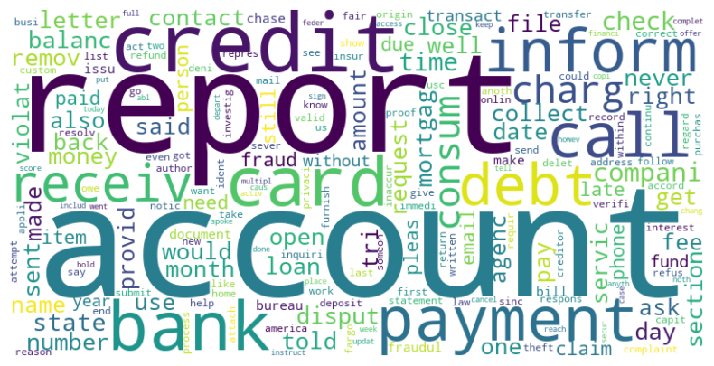

```python
from wordcloud import WordCloud
import matplotlib.pyplot as plt

# Get feature names and their importance
feature_names = tfidf_vectorizer.get_feature_names_out()
feature_importance = tfidf_matrix.sum(axis=0).tolist()[0]

# Create a dictionary of feature names and their importance
feature_dict = {feature_names[i]: feature_importance[i] for i in range(len(feature_names))}

# Generate the word cloud
wordcloud = WordCloud(width=800, height=400, background_color='white').generate_from_frequencies(feature_dict)

# Display the word cloud
plt.figure(figsize=(10, 5))
plt.imshow(wordcloud, interpolation='bilinear')
plt.axis("off")
plt.show()
```

```python
import plotly.graph_objects as go

# Calculate cumulative explained variance
cumulative_explained_var = np.cumsum(svd.explained_variance_ratio_)

# Identify the elbow point
elbow_point = np.argmax(cumulative_explained_var > 0.95)

# Create the Scree plot
fig = go.Figure()

# Add individual explained variance as bars
fig.add_trace(go.Bar(x=list(range(1, num_components + 1)),
                     y=svd.explained_variance_ratio_,
                     name='Individual Explained Variance',
                     marker=dict(color='blue')))

# Add elbow point as a separate scatter point
fig.add_trace(go.Scatter(x=[elbow_point + 1],
                         y=[svd.explained_variance_ratio_[elbow_point]],
                         mode='markers',
                         name='Elbow Point',
                         marker=dict(color='red', size=10)))

# Add labels and title
fig.update_layout(title='Scree Plot with Elbow Point',
                  xaxis_title='Principal Component',
                  yaxis_title='Explained Variance Ratio')

fig.show()
```

[interactive chart not shown]

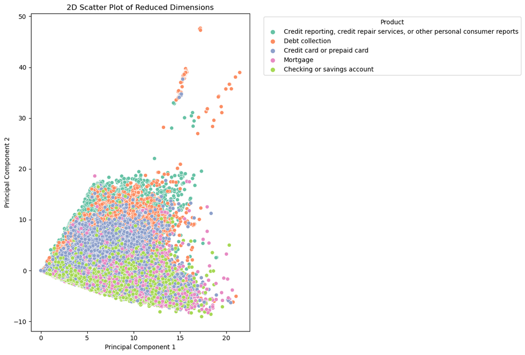

```python
import seaborn as sns

# Create a DataFrame for the scatter plot
scatter_df = pd.DataFrame(tfidf_matrix_reduced[:, :2], columns=['Component_1', 'Component_2'])
scatter_df['Product'] = balanced_df['Product']

# Generate the 2D scatter plot
plt.figure(figsize=(12, 8))
sns.scatterplot(data=scatter_df, x='Component_1', y='Component_2', hue='Product', palette='Set2')
plt.title('2D Scatter Plot of Reduced Dimensions')
plt.xlabel('Principal Component 1')
plt.ylabel('Principal Component 2')
plt.legend(title='Product', bbox_to_anchor=(1.05, 1), loc='upper left')
plt.tight_layout()
plt.show()
```

The 2D Scatter Plot above represents the data points reduced to the first two principal components, colored by their respective 'Product' categories. The plot provides insights into the distribution and potential clustering of different 'Product' categories in the reduced-dimensional space.

1. **Overlapping Categories**: Most of the 'Product' categories appear to be overlapping with each other. This suggests that the first two principal components alone might not be sufficient for distinctly separating the different product types.
2. **Density Variations**: Some areas of the plot exhibit a higher density of data points, indicating potential clusters. These could be regions where complaints regarding specific products are more frequent or similar in nature.
3. **Color Distribution**: The colors representing different 'Product' categories are dispersed throughout the plot. This indicates that the 'Product' attribute alone may not be a strong differentiating factor in this reduced-dimensional space.
4. **Limitation of 2D Visualization**: It's crucial to remember that the plot only shows the first two principal components, which are a reduced representation of the original high-dimensional space. Therefore, clusters or separations that are not visible in this 2D plot may exist in higher dimensions.
5. **Further Analysis Required**: Given the overlap of the categories, it might be beneficial to explore additional features or use more advanced techniques for dimensionality reduction or clustering to achieve better separation.

#### 3.4.1.d Selected Final Features

After the application of feature extraction and dimensionality reduction techniques, we selected a subset of features for the final model. These features are the outcome of applying TF-IDF Vectorization followed by Truncated Singular Value Decomposition (SVD). Below are some key points regarding the final selected features:

1. **Feature Space**: The feature space was reduced to 300 components through Truncated SVD, optimizing both computational efficiency and model performance.
2. **Standardization**: The TF-IDF matrix was standardized using `StandardScaler` to improve the performance of the SVD.
3. **Domain Specificity**: The top features included domain-specific terms like 'credit', 'loan', 'bank', etc., which are highly relevant for classifying financial complaints.
4. **Context Sensitivity**: The feature selection process allowed the model to differentiate between similar terms based on their context, thereby improving classification accuracy.
5. **Interpretable Features**: Despite the dimensionality reduction, the features retained are still interpretable and align well with the financial complaint categories, aiding in understanding the model's decisions.

By carefully selecting these features, the model achieves a balance between complexity and interpretability, ensuring robust performance in classifying customer complaints across various financial products.

### 3.4.2. Model Building or Classifier

With our transformed and dimensionally reduced dataset, we can now proceed to build and evaluate machine learning models for our classification task. We will explore various classification algorithms, including Naive Bayes, Decision Trees, Random Forest, Adaptive Boost and Deep Learning, to determine the most effective model for categorizing consumer complaints.

#### 3.4.2.a Text Classification Experiment Overview

In this section, we present an overview of the text classification experiment conducted on our dataset. The primary objective of this experiment is to classify text data into predefined categories using various machine learning algorithms. The dataset was divided into two subsets: one for training and the other for testing.

###### Algorithms Used

The following machine learning algorithms were selected for the text classification task:

1. **Naive Bayes:** A probabilistic classifier based on Bayes' theorem, commonly used for text classification.
2. **Decision Tree:** A tree-based algorithm that recursively splits data into subsets based on feature values.
3. **Random Forest:** An ensemble learning method that combines multiple decision trees to improve accuracy and control overfitting.
4. **Deep Learning:** Utilizing deep neural networks, specifically designed for handling complex patterns in text data.
5. **Support Vector Machine (SVM):** A powerful algorithm for binary and multiclass text classification.

#### 3.4.2.b Experimental Procedure

The experiment proceeded as follows:

1. **Data Split:** The dataset is divided into two parts: a training set (used for model training) and a testing set (used for model evaluation). The common split ratio is 80% for training and 20% for testing.
2. **Model Building:** Each of the selected algorithms is applied to the training dataset, and the models are trained to classify text data into relevant categories.
3. **Model Evaluation:** The trained models will be then evaluated using the testing dataset. Common evaluation metrics such as accuracy, precision, recall, and F1-score will be computed to assess the model's performance.
4. **Comparison:** The results obtained from each algorithm will be compared to understand their relative performance in text classification.

`1. Data Split:` Split the reduced-dimensionality data (`tfidf_matrix_reduced`) into training and test sets.

```python
from sklearn.model_selection import train_test_split

# Assuming balanced_df['Product'] to be the target labels
X = tfidf_matrix_reduced
y = balanced_df['Product']

# Split the data into training and test sets
X_train, X_test, y_train, y_test = train_test_split(X, y, test_size=0.2, random_state=42)

# Display the shape of the training and test sets
X_train.shape, X_test.shape, y_train.shape, y_test.shape
```

```
((178900, 300), (44726, 300), (178900,), (44726,))
```

`2. Model Building:` Next, we will proceed to train and evaluate the following models:

1. Naive Bayes
2. Decision Trees
3. Random Forest
4. Generalised Linear Model
5. Simple Deep Learning Model

Let's start with the Naive Bayes model.

`2.1. Naive Bayes`: For our financial complaints classification task, Naive Bayes offers a compelling blend of computational efficiency, effectiveness, and interpretability. Its rapid training and prediction times are well-suited for handling high-dimensional text data, and despite its simplicity, it often yields robust classification performance. Additionally, the probabilistic output can provide valuable insights for decision-making.

```python
from sklearn.naive_bayes import GaussianNB
from sklearn.metrics import accuracy_score, classification_report, confusion_matrix
from joblib import dump, load

# Initialize and train the Naive Bayes model
nb_model = GaussianNB()
nb_model.fit(X_train, y_train)

# Save the model to a file
dump(nb_model, 'models/NaiveBayes/nb_model.joblib')

# Make predictions on the test set
nb_predictions = nb_model.predict(X_test)

# Evaluate the model
nb_accuracy = accuracy_score(y_test, nb_predictions)
test_accuracy_nb = round(nb_accuracy * 100, 2)

# Generate the classification report
classification_rep_nb = classification_report(y_test, nb_predictions)

test_accuracy_nb
```

```
39.07
```

The Naive Bayes model achieved an accuracy of approximately `39%` on the test set, which is very poor.

`2.2. Decision Tree`: Decision Trees offer an intuitively understandable model structure that can also handle both categorical and numerical features effectively. Their hierarchical structure allows them to capture complex relationships in the data, providing a balance between performance and interpretability. Additionally, the ability to visualize the decision-making process can offer valuable insights for understanding feature importance and decision logic.

```python
from sklearn.tree import DecisionTreeClassifier

# Initialize and train the Decision Tree model
dt_model = DecisionTreeClassifier(random_state=42)
dt_model.fit(X_train, y_train)

# Save the Decision Tree model to a file
dump(dt_model, 'models/DecisionTree/dt_model.joblib')

# Make predictions on the test set
dt_predictions = dt_model.predict(X_test)

# Evaluate the model
dt_accuracy = accuracy_score(y_test, dt_predictions)

# Generate the classification report
classification_rep_dt = classification_report(y_test, dt_predictions)

test_accuracy_dt = round(dt_accuracy * 100, 2)
test_accuracy_dt
```

```
69.61
```

The Decision Tree model achieved an accuracy of `69%` on the test set, which is an improvement over the Naive Bayes model.

`2.3 Generalised Linear Model`: For text classification tasks such as our financial complaints project, Generalized Linear Models (GLMs) can be a good choice due to their simplicity and efficiency. They work well when the feature space is large but sparse, which is often the case with text data represented as bag-of-words or TF-IDF. Additionally, GLMs provide interpretable model parameters, making it easier to understand the impact of individual words or n-grams in the classification decision.

```python
from sklearn.linear_model import LogisticRegression

# Initialize and train the Generalized Linear Model (Logistic Regression in this case)
glm_model = LogisticRegression(random_state=42)
glm_model.fit(X_train, y_train)

dump(glm_model, 'models/GLM/glm_model.joblib')

# Make predictions on the test set
glm_predictions = glm_model.predict(X_test)

# Evaluate the model
glm_accuracy = accuracy_score(y_test, glm_predictions)

# Generate the classification report
classification_rep_glm = classification_report(y_test, glm_predictions)

# Calculate the test accuracy in percentage
test_accuracy_glm = round(glm_accuracy * 100, 2)

test_accuracy_glm
```

```
83.75
```

`2.4. Random Forest`: This ensemble method can capture complex relationships in the data by aggregating decisions from multiple decision trees. Random Forest is less prone to overfitting compared to individual decision trees, making it a solid choice for classifying text into different categories while maintaining generalizability.

```python
%%time
from sklearn.ensemble import RandomForestClassifier

# Initialize and train the Random Forest model
rf_model = RandomForestClassifier(n_estimators = 100, n_jobs=-1, random_state=42)
rf_model.fit(X_train, y_train)

# Save the model to a file
dump(rf_model, 'models/RandomForest/rf_model.joblib')

# Make predictions on the test set
rf_predictions = rf_model.predict(X_test)

# Evaluate the model
test_accuracy_rf = round(accuracy_score(y_test, rf_predictions) * 100, 2)

# Generate the classification report
classification_rep_rf = classification_report(y_test, rf_predictions)

test_accuracy_rf
```

```
CPU times: total: 39min 48s
Wall time: 4min 12s
```

```
82.14
```

`2.5. Deep Learning Model in TensorFlow`

**Hyperparameter Tuning using [Keras Tuner](https://keras.io/keras_tuner/)**: To perform hyperparameter tuning, we need to use `keras tuner` to define a search space and find the best model.

**Label Encoding target "Product" variable** is used to convert the textual categories in the target variable into numbers. This is necessary because machine learning models, including neural networks, require numerical values for both input features and output labels. Label encoding is a straightforward way to achieve this conversion, making the data compatible and efficient for model training and evaluation

```python
# !pip install keras-tuner

from keras_tuner import RandomSearch
import tensorflow as tf
from sklearn.preprocessing import LabelEncoder

# Initialize label encoder
label_encoder = LabelEncoder()

# Fit and transform y_train and y_test
y_train_encoded = label_encoder.fit_transform(y_train)
y_test_encoded = label_encoder.transform(y_test)

# Convert the data to TensorFlow tensors
X_train_tensor = tf.convert_to_tensor(X_train, dtype=tf.float32)
X_test_tensor = tf.convert_to_tensor(X_test, dtype=tf.float32)
y_train_tensor = tf.convert_to_tensor(y_train_encoded, dtype=tf.float32)
y_test_tensor = tf.convert_to_tensor(y_test_encoded, dtype=tf.float32)


def build_model(hp):
    """
    Build and compile a TensorFlow model for hyperparameter optimization.

    Args:
    hp (keras_tuner.HyperParameters): Hyperparameters to optimize.

    Returns:
    tf.keras.Model: Compiled model with specified hyperparameters.
    """

    # Initialize the model as a Sequential model
    model = tf.keras.Sequential()

    # Add the first Dense layer with hyperparameter-optimized number of units and 'relu' activation
    # The input shape is based on the number of features in the dataset
    model.add(tf.keras.layers.Dense(units=hp.Int('units_1', min_value=32, max_value=128, step=32),
                                    activation='relu',
                                    input_shape=(X_train.shape[1],)))

    # Add the second Dense layer with hyperparameter-optimized number of units and 'relu' activation
    model.add(tf.keras.layers.Dense(units=hp.Int('units_2', min_value=16, max_value=64, step=16),
                                    activation='relu'))

    # Add the output Dense layer with softmax activation
    # The number of units is equal to the number of unique target labels
    model.add(tf.keras.layers.Dense(len(np.unique(y_train_encoded)), activation='softmax'))

    # Compile the model with a hyperparameter-optimized learning rate
    # The loss function is sparse_categorical_crossentropy and the metric is accuracy
    model.compile(optimizer=tf.keras.optimizers.Adam(hp.Choice('learning_rate', values=[1e-2, 1e-3, 1e-4])),
                  loss='sparse_categorical_crossentropy',
                  metrics=['accuracy'])

    return model

# Initialize the tuner
tuner = RandomSearch(build_model, objective='val_accuracy', max_trials=12, executions_per_trial=2)

# Perform hyperparameter search
tuner.search(X_train_tensor, y_train_tensor, epochs=10, validation_split=0.05)

# Get the optimal hyperparameters
best_hps = tuner.get_best_hyperparameters(num_trials=1)[0]
```

```
INFO:tensorflow:Reloading Tuner from .\untitled_project\tuner0.json
INFO:tensorflow:Oracle triggered exit
```

##### Keras Tuner Code Summary in Tabular Format

| Section | Details |
| --- | --- |
| **Function Name** | `build_model(hp)` |
| **Function Purpose** | Build and compile a TensorFlow neural network tailored for hyperparameter optimization. |
| **Input Parameter** | `hp` (HyperParameters object for specifying hyperparameters to optimize) |
| **Return Value** | Compiled TensorFlow model with specified hyperparameters |
| **First Dense Layer** | - Activated with 'ReLU' - Units are a hyperparameter (32 to 128) - Input shape based on dataset features |
| **Second Dense Layer** | - Activated with 'ReLU' - Units are a hyperparameter (16 to 64) |
| **Output Layer** | - 'Softmax' activation - Units equal to unique target labels |
| **Compilation** | - Adam optimizer - Hyperparameter-optimized learning rate - Loss: `sparse_categorical_crossentropy` - Metric: Accuracy |
| **Tuner Type** | `RandomSearch` |
| **Objective** | Maximize `val_accuracy` |
| **Number of Trials** | 12 |
| **Executions/Trial** | 2 |
| **Epochs** | 10 |
| **Validation Split** | 5% of the training data |
| **Best Hyperparameters** | Retrieved using `tuner.get_best_hyperparameters` |

Now let us see which trials can yield a best training.

```python
# Initialize an empty list to hold the trial data
trial_data = []

# Loop through each trial object in the tuner's trials dictionary
for trial in tuner.oracle.trials.values():
    trial_info = {
        'Trial ID': trial.trial_id,
        'Score': trial.score,
        'Layer 1 Units': trial.hyperparameters.values['units_1'],
        'Layer 2 Units': trial.hyperparameters.values['units_2'],
        'Learning Rate': trial.hyperparameters.values['learning_rate']
    }
    trial_data.append(trial_info)

# Create a Pandas DataFrame from the list of trial data
df_trials = pd.DataFrame(trial_data)

# Display the DataFrame
df_trials
```

|  | Trial ID | Score | Layer 1 Units | Layer 2 Units | Learning Rate |
| --- | --- | --- | --- | --- | --- |
| 0 | 05 | 0.852152 | 64 | 64 | 0.0010 |
| 1 | 01 | 0.833035 | 64 | 16 | 0.0100 |
| 2 | 09 | 0.850475 | 64 | 48 | 0.0010 |
| 3 | 00 | 0.851928 | 128 | 32 | 0.0001 |
| 4 | 06 | 0.853326 | 128 | 64 | 0.0010 |
| 5 | 02 | 0.849469 | 64 | 48 | 0.0001 |
| 6 | 03 | 0.850140 | 128 | 16 | 0.0001 |
| 7 | 11 | 0.837451 | 32 | 32 | 0.0100 |
| 8 | 04 | 0.847904 | 32 | 16 | 0.0001 |
| 9 | 07 | 0.851146 | 32 | 16 | 0.0010 |
| 10 | 08 | 0.850028 | 32 | 32 | 0.0010 |
| 11 | 10 | 0.830296 | 96 | 16 | 0.0100 |

`Observations from the Table:`

1. **Highest Accuracy**: The highest validation accuracy is approximately 85.3% in Trial ID 06.
2. **Optimal Hyperparameters**: The optimal set of hyperparameters appears to be 128 units for the first layer, 64 units for the second layer, and a learning rate of 0.001. These settings resulted in the highest validation accuracy.
3. **Learning Rate Sensitivity**: Trials with learning rates of 0.0001 or 0.001 generally performed better, suggesting that the model is sensitive to the learning rate.
4. **Units in Hidden Layers**: More units in the first layer (128) and more units in the second layer (64) appear to yield the best performance.

```python
# Get the optimal hyperparameters from the tuner
best_hps = tuner.get_best_hyperparameters(num_trials=1)[0]

# Extract the best hyperparameters
best_units_1 = best_hps.get('units_1')
best_units_2 = best_hps.get('units_2')
best_learning_rate = best_hps.get('learning_rate')

# Output the best hyperparameters
print(f"The optimal number of units are layer 1 - {best_units_1}, layer 2 - {best_units_2} and the optimal learning rate is {best_learning_rate}.")
```

```
The optimal number of units are layer 1 - 128, layer 2 - 64 and the optimal learning rate is 0.001.
```

```python
# Optionally, get the best model to view its summary
best_model = tuner.get_best_models(num_models=1)[0]

# Save the best model architecture and weights
best_model.save("models/DeepLearning/best_model.h5")

best_model.summary()
```

```
Model: "sequential"
_________________________________________________________________
 Layer (type)                Output Shape              Param #
=================================================================
 dense (Dense)               (None, 128)               38528

 dense_1 (Dense)             (None, 64)                8256

 dense_2 (Dense)             (None, 5)                 325

=================================================================
Total params: 47109 (184.02 KB)
Trainable params: 47109 (184.02 KB)
Non-trainable params: 0 (0.00 Byte)
_________________________________________________________________
```

```python
import os
from tensorflow.keras.models import load_model

# Check if the model file exists
if os.path.exists("models/DeepLearning/final_model.h5"):
    # Load the pre-trained model
    print("Loading existing model.")
    final_model = load_model("models/DeepLearning/final_model.h5")
    final_history = None
else:
    # If the model doesn't exist, train a new one and save it
    print("Training new model.")

    # Now Create the model architecture with best hyperparameters
    final_model = tf.keras.Sequential([
        tf.keras.layers.Dense(best_units_1, activation='relu', input_shape=(X_train.shape[1],)),
        tf.keras.layers.Dense(best_units_2, activation='relu'),
        tf.keras.layers.Dense(len(np.unique(y_train_encoded)), activation='softmax')  # Number of unique labels
    ])

    # Compile the model
    final_model.compile(optimizer=tf.keras.optimizers.Adam(learning_rate=best_learning_rate),
                        loss='sparse_categorical_crossentropy',
                        metrics=['accuracy'])

    # Train the model
    final_history = final_model.fit(X_train_tensor, y_train_tensor, epochs=10, batch_size=32)

    # Save the trained model
    final_model.save("models/DeepLearning/final_model.h5")
```

```
Loading existing model.
```

If we have trained the model, lets look into the learning curves.

```python
if final_history:
    fig, (ax1, ax2) = plt.subplots(1, 2, figsize=(12, 4))

    # Plotting Accuracy vs Epochs
    ax1.plot(final_history.history['accuracy'], label='Training Accuracy')
    ax1.set_xlabel('Epochs')
    ax1.set_ylabel('Accuracy')
    ax1.set_title('Accuracy vs Epochs')
    ax1.legend()

    # Plotting Loss vs Epochs
    ax2.plot(final_history.history['loss'], label='Training Loss')
    ax2.set_xlabel('Epochs')
    ax2.set_ylabel('Loss')
    ax2.set_title('Loss vs Epochs')
    ax2.legend()

    plt.tight_layout()
    plt.show()
```

```python
from sklearn.metrics import classification_report

# Evaluate the model on the test set
test_loss, test_accuracy = final_model.evaluate(X_test_tensor, y_test_tensor, verbose=0)

# Predict the labels of the test set
y_pred = final_model.predict(X_test_tensor)
y_pred_classes = np.argmax(y_pred, axis=1)

# Generate the classification report
classification_rep_dl = classification_report(y_test_encoded, y_pred_classes, target_names=label_encoder.classes_)

print(f"Test Accuracy: {test_accuracy * 100:.2f}%")
test_accuracy_dl = round(test_accuracy * 100, 2)
test_accuracy_dl
# print("Classification Report:")
# print(classification_rep_dl)
```

```
Test Accuracy: 76.80%
```

```
76.8
```

## 3.5 Evaluation or Validation

### Importance of Comparing Test Accuracies in Text Classification

Comparing test accuracies across different models is crucial for our text classification task, especially given the high-dimensional and sparse nature of the Customer Complaints Narrative data. Test accuracy serves as an unbiased metric that directly reflects a model's ability to generalize to unseen data. Since our task involves categorizing textual data into specific classes, a slight variation in accuracy can significantly impact the model's utility in real-world applications. Therefore, assessing models solely based on their test accuracy helps us to objectively select the best-performing model for our specific use-case.

```python
models = ['Naive Bayes', 'Decision Trees', 'Random Forest', 'GLM', 'Neural Network']
accuracies = [test_accuracy_nb, test_accuracy_dt, test_accuracy_rf, test_accuracy_glm, test_accuracy_dl]

# Create a DataFrame for the data
df = pd.DataFrame({'Models': models, 'Accuracies': accuracies})

# Create a color list and update the color of the best-performing model to 'gold'
colors = ['blue', 'green', 'red', 'purple', 'orange']
best_index = np.argmax(accuracies)
colors[best_index] = 'gold'

# Create the bar chart
fig = go.Figure(data=[go.Bar(
    x=df['Models'],
    y=df['Accuracies'],
    text=df['Accuracies'],
    textposition='auto',
    marker_color=colors
)])

# Customize the layout
fig.update_layout(
    title='Model Performance (in %) in Classifying Financial Products',
    xaxis_title='Models',
    yaxis_title='Test Accuracy (%)',
    template='plotly_white',
    title_x=0.5,
    width=800,  # Width of the figure in pixels
    height=400  # Height of the figure in pixels
)

# Show the plot
fig.show()
```

[interactive chart not shown]

It seems Random Forest and GLM outperforms other models with respect to accuracy on test set. But we need to check the precision of individual Product prediction too under this models.

#### 3.5.1 Naive Bayes

```python
def float_to_int(value):
    """
    Convert float values with trailing zeros to integers.

    Parameters:
    - value (float): The float value to be converted.

    Returns:
    - int: The integer representation of the input float.
    """
    return int(value)

def generate_performance_metrics(X_train, y_train, X_test, y_test, label_encoder, model_path=None):
    """
    Generate performance metrics including a performance table and an enhanced confusion matrix.

    Parameters:
    - X_train (array-like): The training feature matrix.
    - y_train (array-like): The training target vector.
    - X_test (array-like): The test feature matrix.
    - y_test (array-like): The test target vector.
    - label_encoder (LabelEncoder): The label encoder used for transforming target classes.
    - model_path (str, optional): The file path to the saved machine learning model.

    Returns:
    - performance_table (DataFrame): A table containing training and testing accuracies and classification errors.
    - df_cm (DataFrame): An enhanced confusion matrix with Class Precision and Class Recall.
    """

    # Load the saved model
    loaded_model = load(model_path)

    # Perform prediction on the training set
    train_predictions = loaded_model.predict(X_train)

    # Calculate the training accuracy
    train_accuracy = round(accuracy_score(y_train, train_predictions) * 100, 2)

    # Perform prediction on the test set
    test_predictions = loaded_model.predict(X_test)

    # Calculate the test accuracy
    test_accuracy = round(accuracy_score(y_test, test_predictions) * 100, 2)

    # Create the performance table
    performance_data = {
        'Criterion': ['Training Accuracy', 'Testing Accuracy',
                      'Training Classification Error', 'Testing Classification Error'],
        'Value': [train_accuracy, test_accuracy, 100 - train_accuracy, 100 - test_accuracy]
    }
    performance_table = pd.DataFrame(performance_data)

    # Generate the confusion matrix
    cm = confusion_matrix(y_test, test_predictions)

    # Create a DataFrame for better visualization
    actual_labels = ['Actual: ' + str(label) for label in label_encoder.classes_]
    pred_labels = ['Pred: ' + str(label) for label in label_encoder.classes_]

    # Create DataFrame for the confusion matrix
    df_cm = pd.DataFrame(cm, index=actual_labels, columns=pred_labels)

    # Calculating Class Precision and Class Recall
    precision_row = (df_cm.values.diagonal() / df_cm.values.sum(axis=0)) * 100
    recall_col = (df_cm.values.diagonal() / df_cm.values.sum(axis=1)) * 100

    # Add Class Precision row and Class Recall column to the DataFrame
    df_cm.loc['Precision (in %)'] = precision_row
    df_cm['Recall (in %)'] = np.append(recall_col, np.nan)

    # Convert float values with trailing zeros to integers, excluding 'Recall (in %)'
    for col in df_cm.columns:
        if col not in ['Recall (in %)']:
            df_cm[col] = df_cm[col].apply(float_to_int)

    return performance_table, df_cm
```

```python
performance_table_nb, conf_matrix_nb = generate_performance_metrics(X_train, y_train,
                                                                    X_test, y_test, label_encoder,
                                                                    model_path='models/NaiveBayes/nb_model.joblib')
performance_table_nb
```

|  | Criterion | Value |
| --- | --- | --- |
| 0 | Training Accuracy | 38.84 |
| 1 | Testing Accuracy | 39.07 |
| 2 | Training Classification Error | 61.16 |
| 3 | Testing Classification Error | 60.93 |

```python
conf_matrix_nb
```

|  | Pred: Checking or savings account | Pred: Credit card or prepaid card | Pred: Credit reporting, credit repair services, or other personal consumer reports | Pred: Debt collection | Pred: Mortgage | Recall (in %) |
| --- | --- | --- | --- | --- | --- | --- |
| Actual: Checking or savings account | 8082 | 618 | 153 | 439 | 118 | 85.887354 |
| Actual: Credit card or prepaid card | 7906 | 1606 | 354 | 786 | 121 | 14.907639 |
| Actual: Credit reporting, credit repair services, or other personal consumer reports | 3901 | 460 | 3724 | 729 | 117 | 41.697458 |
| Actual: Debt collection | 5245 | 982 | 945 | 1318 | 281 | 15.026793 |
| Actual: Mortgage | 3366 | 110 | 149 | 470 | 2746 | 40.140330 |
| Precision (in %) | 28 | 42 | 69 | 35 | 81 | NaN |

`Naive Bayes Prediction Observations:`

[output not shown]

#### 3.5.2 Decision Trees

```python
performance_table_dt, conf_matrix_dt = generate_performance_metrics(X_train, y_train,
                                                                    X_test, y_test, label_encoder,
                                                                    model_path='models/DecisionTree/dt_model.joblib')

performance_table_dt
```

|  | Criterion | Value |
| --- | --- | --- |
| 0 | Training Accuracy | 99.88 |
| 1 | Testing Accuracy | 69.61 |
| 2 | Training Classification Error | 0.12 |
| 3 | Testing Classification Error | 30.39 |

```python
conf_matrix_dt
```

|  | Pred: Checking or savings account | Pred: Credit card or prepaid card | Pred: Credit reporting, credit repair services, or other personal consumer reports | Pred: Debt collection | Pred: Mortgage | Recall (in %) |
| --- | --- | --- | --- | --- | --- | --- |
| Actual: Checking or savings account | 6533 | 1922 | 263 | 423 | 269 | 69.426142 |
| Actual: Credit card or prepaid card | 2011 | 6653 | 834 | 862 | 413 | 61.756242 |
| Actual: Credit reporting, credit repair services, or other personal consumer reports | 251 | 812 | 6453 | 1173 | 242 | 72.253947 |
| Actual: Debt collection | 349 | 815 | 1256 | 6015 | 336 | 68.578269 |
| Actual: Mortgage | 254 | 435 | 272 | 398 | 5482 | 80.134483 |
| Precision (in %) | 69 | 62 | 71 | 67 | 81 | NaN |

`Decision Tree Model Performance Insights:`

[output not shown]

#### 3.5.3 Neural Nets

```python
_, train_accuracy = final_model.evaluate(X_train_tensor, y_train_tensor, verbose=0)
_, test_accuracy = final_model.evaluate(X_test_tensor, y_test_tensor, verbose=0)

print(f"Train Accuracy from neural nets: {round(train_accuracy * 100, 2)}\nTest Accuracy from neural nets: {round(test_accuracy * 100, 2)}")
```

```
Train Accuracy from neural nets: 77.19
Test Accuracy from neural nets: 76.8
```

```python
print(classification_rep_dl)
```

```
                                                                              precision    recall  f1-score   support

                                                 Checking or savings account       0.76      0.81      0.78      9410
                                                 Credit card or prepaid card       0.72      0.70      0.71     10773
Credit reporting, credit repair services, or other personal consumer reports       0.80      0.69      0.74      8931
                                                             Debt collection       0.72      0.79      0.76      8771
                                                                    Mortgage       0.88      0.89      0.88      6841

                                                                    accuracy                           0.77     44726
                                                                   macro avg       0.78      0.78      0.77     44726
                                                                weighted avg       0.77      0.77      0.77     44726
```

`Neural Nets Prediction Observations:`

[output not shown]

#### 3.5.4 Random Forest

```python
performance_table_rf, conf_matrix_rf = generate_performance_metrics(X_train, y_train,
                                                                    X_test, y_test, label_encoder,
                                                                    model_path='models/RandomForest/rf_model.joblib')

performance_table_rf
```

|  | Criterion | Value |
| --- | --- | --- |
| 0 | Training Accuracy | 99.88 |
| 1 | Testing Accuracy | 82.14 |
| 2 | Training Classification Error | 0.12 |
| 3 | Testing Classification Error | 17.86 |

```python
conf_matrix_rf
```

|  | Pred: Checking or savings account | Pred: Credit card or prepaid card | Pred: Credit reporting, credit repair services, or other personal consumer reports | Pred: Debt collection | Pred: Mortgage | Recall (in %) |
| --- | --- | --- | --- | --- | --- | --- |
| Actual: Checking or savings account | 7903 | 1188 | 90 | 147 | 82 | 83.985122 |
| Actual: Credit card or prepaid card | 1401 | 8390 | 456 | 436 | 90 | 77.879885 |
| Actual: Credit reporting, credit repair services, or other personal consumer reports | 99 | 639 | 7282 | 777 | 134 | 81.536222 |
| Actual: Debt collection | 152 | 560 | 774 | 7116 | 169 | 81.131000 |
| Actual: Mortgage | 220 | 303 | 109 | 161 | 6048 | 88.408127 |
| Precision (in %) | 80 | 75 | 83 | 82 | 92 | NaN |

`Random Forest Prediction Observations:`

[output not shown]

#### 3.5.5 Generalized Linear Model or Logistics Regression

```python
performance_table_glm, conf_matrix_glm = generate_performance_metrics(X_train, y_train,
                                                                    X_test, y_test, label_encoder,
                                                                    model_path='models/GLM/glm_model.joblib')

performance_table_glm
```

|  | Criterion | Value |
| --- | --- | --- |
| 0 | Training Accuracy | 84.06 |
| 1 | Testing Accuracy | 83.75 |
| 2 | Training Classification Error | 15.94 |
| 3 | Testing Classification Error | 16.25 |

```python
conf_matrix_glm
```

|  | Pred: Checking or savings account | Pred: Credit card or prepaid card | Pred: Credit reporting, credit repair services, or other personal consumer reports | Pred: Debt collection | Pred: Mortgage | Recall (in %) |
| --- | --- | --- | --- | --- | --- | --- |
| Actual: Checking or savings account | 8081 | 1042 | 73 | 127 | 87 | 85.876727 |
| Actual: Credit card or prepaid card | 1185 | 8621 | 483 | 397 | 87 | 80.024134 |
| Actual: Credit reporting, credit repair services, or other personal consumer reports | 85 | 529 | 7358 | 844 | 115 | 82.387191 |
| Actual: Debt collection | 131 | 479 | 921 | 7088 | 152 | 80.811766 |
| Actual: Mortgage | 143 | 140 | 114 | 133 | 6311 | 92.252595 |
| Precision (in %) | 83 | 79 | 82 | 82 | 93 | NaN |

[output not shown]

#### 3.5.6 Overall Performances

```python
# Importing required libraries again
import pandas as pd

# Creating a DataFrame with model performance statistics
model_performance_stats = {
    'Model': ['GLM', 'Random Forest', 'Neural Networks', 'Decision Trees', 'Naive Bayes'],
    'Overall Accuracy (%)': [test_accuracy_glm, test_accuracy_rf, test_accuracy_dl, test_accuracy_dt, test_accuracy_nb],
    'Best Class Precision (%)': [conf_matrix_glm.iloc[5].max(),
                                 conf_matrix_rf.iloc[5].max(),
                                 88,
                                 conf_matrix_dt.iloc[5].max(),
                                 conf_matrix_nb.iloc[5].max()],
    'Best Class Recall (%)': [conf_matrix_glm['Recall (in %)'].max(),
                              conf_matrix_rf['Recall (in %)'].max(),
                              90,
                              conf_matrix_dt['Recall (in %)'].max(),
                              conf_matrix_nb['Recall (in %)'].max()],
    'Worst Class Precision (%)': [conf_matrix_glm.iloc[5].min(),
                                 conf_matrix_rf.iloc[5].min(),
                                 69,
                                 conf_matrix_dt.iloc[5].min(),
                                 conf_matrix_nb.iloc[5].min()],
    'Worst Class Recall (%)': [conf_matrix_glm['Recall (in %)'].min(),
                              conf_matrix_rf['Recall (in %)'].min(),
                              70,
                              conf_matrix_dt['Recall (in %)'].min(),
                              conf_matrix_nb['Recall (in %)'].min()]
}

# Creating a DataFrame and sorting it by 'Overall Accuracy (%)' in descending order
df_model_performance_stats = pd.DataFrame(model_performance_stats)
df_model_performance_stats = df_model_performance_stats.sort_values(by='Overall Accuracy (%)',
                                                                    ascending=False).reset_index(drop=True)

df_model_performance_stats
```

[output not shown]

As seen, the `Generalized Linear Model (GLM)` outperforms all other models in terms of overall accuracy, best class precision, and best class recall. It is followed by Random Forest and Neural Networks. Naive Bayes, despite having a good best class recall, performs poorly in worst class precision and recall, making it the least favorable option for our case.

#### 3.5.7 Observations on GLM Feature Importance

Let us implement a code which will first extract the `Singular Value Decomposition (SVD)` components and the feature names from the TF-IDF vectorizer, followed by obtaining the `Generalized Linear Model (GLM)` coefficients. Then, these coefficients will be mapped back to the original feature space through a dot product operation. A Pandas DataFrame will be created to store these mapped coefficients, indexed by class labels and columned by feature names. For each class label, the code will sort the coefficients in descending order to identify the top 30 most influential features, storing these in a dictionary. Finally, this dictionary will be converted into a DataFrame for easier interpretation and presentation.

```python
# Get SVD components and feature names
svd_components = svd.components_
feature_names = tfidf_vectorizer.get_feature_names_out()

# Get the coefficients from the GLM model
glm_coefficients = glm_model.coef_

# Map the GLM coefficients back to the original feature space
mapped_coefficients = np.dot(glm_coefficients, svd_components)

# Create a DataFrame for easier manipulation
df_mapped_coefficients = pd.DataFrame(mapped_coefficients, columns=feature_names, index=label_encoder.classes_)

# Initialize an empty dictionary to store sorted coefficients for each class
sorted_coefs_dict = {}

# For each class, sort the coefficients to get the most influential features
for class_label in label_encoder.classes_:
    sorted_coef = df_mapped_coefficients.loc[class_label].sort_values(ascending=False)
    sorted_coefs_dict[class_label] = list(sorted_coef.head(30).keys().values)

top_keywords = pd.DataFrame(sorted_coefs_dict)
top_keywords
```

|  | Checking or savings account | Credit card or prepaid card | Credit reporting, credit repair services, or other personal consumer reports | Debt collection | Mortgage |
| --- | --- | --- | --- | --- | --- |
| 0 | bank | card | report | debt | mortgag |
| 1 | deposit | charg | credit | collect | loan |
| 2 | check | purchas | remov | owe | escrow |
| 3 | account | use | bureau | compani | home |
| 4 | money | credit | inquiri | collector | refin |
| 5 | fund | gift | score | recoveri | properti |
| 6 | save | capit | inaccur | origin | payment |
| 7 | overdraft | limit | equifax | llc | modif |
| 8 | branch | one | experian | report | tax |
| 9 | transact | reward | inform | inc | refinanc |
| 10 | fargo | visa | transunion | agenc | mr |
| 11 | close | store | updat | harass | apprais |
| 12 | well | interest | agenc | medic | cooper |
| 13 | fee | express | date | bill | foreclosur |
| 14 | bonu | american | item | alleg | lender |
| 15 | withdraw | mastercard | delet | credit | homeown |
| 16 | debit | synchroni | incorrect | creditor | pmi |
| 17 | access | comen | section | paid | princip |
| 18 | open | merchant | hard | valid | insur |
| 19 | america | custom | accord | amount | forbear |
| 20 | charg | minimum | fcra | contract | hous |
| 21 | transfer | vanilla | creditor | portfolio | process |
| 22 | claim | replac | follow | attempt | analysi |
| 23 | chase | balanc | balanc | threaten | shortag |
| 24 | fraud | appli | correct | settl | equiti |
| 25 | direct | prepaid | theft | never | underwrit |
| 26 | overdrawn | promot | ident | remov | freedom |
| 27 | chime | refund | collect | contact | payoff |
| 28 | custom | declin | list | fdcpa | valu |
| 29 | banker | late | erron | sold | fha |

```python
# top_keywords.to_csv('top_keywords.csv')
```

##### General Observations

- The selected features seem to be strongly indicative of the corresponding financial product complaint categories.

`Checking or Savings Account`

- Words like `bank`, `deposit`, and `overdraft` are expectedly high-ranking features. These terms are commonly associated with complaints about checking or savings accounts.

`Credit Card or Prepaid Card`

- Terms such as `card`, `charge`, and `credit` dominate the list. Interestingly, specific card companies like `capital` and `american` also appear, suggesting that the model might be sensitive to the issuer's name.

`Credit Reporting, Credit Repair Services, or Other Personal Consumer Reports`

- The list includes names of credit reporting agencies like `equifax` and `transunion`, along with related terms like `report` and `credit`. These are critical keywords often found in credit reporting complaints.

`Debt Collection`

- Words commonly associated with debt collection activities, such as `debt`, `collect`, and `owe`, are high-ranking features. The presence of words like `harass` might indicate complaints related to aggressive collection practices.

`Mortgage`

- As expected, terms like `mortgage`, `loan`, and `home` are important features. Other terms like `refin`, `foreclosure`, and `lender` indicate specific types of mortgage complaints.

`Notable Patterns Across Categories`

- Some terms appear across multiple categories but have different implications. For example, the term `credit` appears in both 'Credit Card or Prepaid Card' and 'Credit Reporting, Credit Repair Services, or Other Personal Consumer Reports,' serving different contextual roles.

These observations provide a valuable understanding of how the GLM model interprets different complaint categories based on specific key terms.

##### Some More Observations

|  | Checking or Savings Account | Credit Card or Prepaid Card | Credit Reporting, Repair, etc. | Debt Collection | Mortgage |
| --- | --- | --- | --- | --- | --- |
| **Example Keywords** | `check`, `account`, `money`, `fund`, `save`, `branch`, `overdraft`, `withdraw`, `access`, `america` | `purchase`, `limit`, `interest`, `gift`, `visa`, `mastercard`, `merchant`, `minimum`, `replace`, `prepaid` | `remove`, `bureau`, `inquiry`, `score`, `inaccurate`, `update`, `item`, `delete`, `incorrect`, `section` | `owe`, `company`, `recovery`, `origin`, `llc`, `inc`, `bill`, `medical`, `valid`, `creditor` | `escrow`, `property`, `refinance`, `payment`, `tax`, `modification`, `foreclosure`, `appraisal`, `homeowner`, `insurance` |
| **Description** | Keywords like `check` and `account` are central to checking or savings accounts. The term `withdraw` might point to complaints about unauthorized withdrawals. | The terms `purchase` and `limit` may refer to transaction limitations or issues, while `interest` likely relates to interest rate complaints. `Merchant` could point to disputes with merchant charges. | Keywords like `bureau` and `inquiry` indicate issues with credit reporting agencies. The term `inaccurate` might pertain to complaints about incorrect information. | Terms like `recovery` and `origin` may point to the origin of the debt or recovery actions. `Bill` and `medical` could indicate the type of debt. | `Escrow` and `property` indicate issues related to mortgage escrow accounts and property, respectively. The term `foreclosure` suggests severe issues with mortgage payments. |

**`Key Takeaways from GLM feature importance:`**

- The GLM model's feature importance not only confirms expected terms but also highlights specialized terms like `withdraw` for Checking or Savings Account and `inquiry` for Credit Reporting.
- The presence of additional terms like `merchant` for Credit Card or Prepaid Card and `medical` for Debt Collection indicates the model's nuanced understanding of these categories.
- The model is likely well-suited for distinguishing between different types of financial product complaints, given the relevance of the identified keywords.

#### 3.5.8 Leveraging ML Models for Consumer Complaint Classification and Experience Enhancement

**`Addressing RQ1: Role of Consumer Complaint Narratives in Classification`**

The observations from the GLM feature importance table directly address the research question (RQ1) by revealing **how consumer complaint narratives play a crucial role in the accurate classification of complaints across various financial products.**

1. **Keyword Specificity**: The high-ranking keywords for each category are mostly specialized terms directly related to the respective financial products. For example, terms like `escrow` and `foreclosure` are specific to mortgage-related complaints, while `overdraft` and `withdraw` are specific to checking or savings accounts. This specificity aids in accurate classification.
2. **Contextual Understanding**: Some keywords like `credit` appear in multiple categories but serve different contextual roles. This indicates that the model is capable of understanding the contextual importance of words, further aiding in precise categorization.
3. **Nuanced Complaint Types**: The presence of additional terms like `merchant` for Credit Card or Prepaid Card and `medical` for Debt Collection shows that the model can distinguish between subtypes within a category, making classification more granular and accurate.
4. **Model Robustness**: The wide range of identified keywords suggests that the model has learned from the complaint narratives in a robust manner, capturing various aspects of consumer complaints. This is vital for effectively categorizing these complaints into the appropriate financial product categories.
5. **Consumer Behavior Insights**: The feature importance list also gives an insight into what consumers commonly complain about, which is valuable information for financial institutions aiming to improve their services.

By highlighting these aspects, the model demonstrates that consumer complaint narratives are indeed invaluable for the accurate and nuanced classification of complaints into different financial product categories. This directly addresses the aim of comprehending the role of consumer complaint narratives in effective categorization, as stated in RQ1.

**`Addressing RQ2: Enhancing Consumer Experience with Different Classification Methods.`**

Absolutely, the multiple models tested, including Naive Bayes, Decision Trees, Neural Networks, Random Forests, and Generalized Linear Models (GLMs), each contribute uniquely to addressing Research Question 2 (RQ2) about enhancing consumer experience through machine learning.

1. **Model Diversity for Robustness**: Using various classification methods ensures that we capture different types of patterns in the data, thereby making the overall system more robust. For instance, while Naive Bayes may be good for quick initial classification, GLMs may offer more accurate and nuanced categorization.
2. **Trade-off Between Accuracy and Interpretability**: Different models offer different balances between accuracy and interpretability. For example, Decision Trees are easy to interpret and could be used to explain the classification process to consumers, thereby enhancing transparency. On the other hand, Neural Networks, although less interpretable, might offer better accuracy.
3. **Customized Responses**: Based on the model's ability to accurately classify complaints into subtypes (e.g., `medical` for Debt Collection, `merchant` for Credit Card), financial institutions can offer more personalized and targeted responses, improving consumer satisfaction.
4. **Scalability and Efficiency**: Some models are computationally less intensive than others and can offer quick classifications. This is crucial for real-time consumer interaction and enhances the user experience by reducing waiting times for complaint resolution.
5. **Continuous Improvement**: The metrics gathered from each model's performance can be used for continuous improvement. For instance, areas where a model is weak can be improved upon in future iterations, continually enhancing the consumer experience.
6. **Consumer Trust**: A well-functioning, accurate classification system can build consumer trust, as it signals that the financial institution is taking consumer complaints seriously and is committed to resolving them efficiently.

By leveraging the strengths of different classification methods, financial institutions can significantly enhance the consumer experience, from the moment a complaint is filed to how quickly and accurately it is resolved. This addresses the goal of enhancing consumer experience through machine learning, as outlined in RQ2.

#### 3.5.9 Unit Testing

`About Unittesting Notebook`

In addition to the main `CustomerComplaintImplementation.ipynb` notebook, a separate Python script named `unittesting.py` is also provided in the repository. This script contains unit tests designed to validate various components of the codebase such as data loading, preprocessing, model training, and evaluation.

`How to Run Unittesting.py`:

1. **Navigate to the Directory**: Open a terminal and navigate to the folder containing `unittesting.py`.
2. **Run the Script**: Execute the command `python unittesting.py`. This will run all the unit tests and you should see an output indicating the status of each test (Pass/Fail).

By running the unittesting script, we can ensure that all the major functionalities are working as expected, making the codebase more robust and reliable.

# 4. Conclusion

In this research, we have undertaken a comprehensive investigation into the classification of consumer complaints into different [financial product categories](https://www.consumerfinance.gov/complaint/), focusing on narratives provided to the [Consumer Financial Protection Bureau (CFPB)](https://www.consumerfinance.gov/). By employing a variety of machine learning classifiers—[Naive Bayes](https://en.wikipedia.org/wiki/Naive_Bayes_classifier), [Decision Trees](https://en.wikipedia.org/wiki/Decision_tree), [Neural Networks](https://en.wikipedia.org/wiki/Artificial_neural_network), [Random Forests](https://en.wikipedia.org/wiki/Random_forest), and [Generalized Linear Models (GLMs)](https://en.wikipedia.org/wiki/Generalized_linear_model)—we have not only evaluated the effectiveness of these models but also gauged their potential impact on both [regulatory oversight](https://www.consumerfinance.gov/policy-compliance/enforcement/) and [consumer experience](https://www.consumerfinance.gov/consumer-tools/).

Our comparative analyses, articulated through performance metrics and [feature importance](https://en.wikipedia.org/wiki/Feature_selection) insights, reveal that the Generalized Linear Model (GLM) manifests superior accuracy. This heightened accuracy comes without sacrificing [computational efficiency](https://en.wikipedia.org/wiki/Computational_complexity), thereby making it a favorable choice for real-time classification tasks.

While the models differ in their individual strengths, they all serve to complement the efforts of human analysts at CFPB, providing them with robust, accurate, and quick initial classifications. Such automation is particularly valuable for scaling the [review process](https://www.consumerfinance.gov/complaint/process/) and ensuring that complaints are efficiently routed to the correct departments for timely resolution. Although these machine learning approaches are robust, they are intended to [augment, not replace, human expertise](https://en.wikipedia.org/wiki/Automated_machine_learning#Human-in-the-loop_machine_learning). The aim is to equip CFPB analysts with tools that enable more effective and efficient processing of consumer complaints, thereby enhancing the overall consumer experience in financial markets. The methodologies and findings presented herein hold promise for [future operationalization](https://en.wikipedia.org/wiki/Operationalization), continually adapting to new complaint narratives and contributing to the evolution of consumer financial protection mechanisms.

# 5. Future Work

1. **Hyperparameter Tuning**: More extensive hyperparameter tuning could improve the performance of the existing models.
2. **Temporal Analysis**: Investigating the temporal trends in consumer complaints may offer additional insights into the effectiveness of financial institutions in addressing consumer concerns.
3. **Text Preprocessing**: Advanced text preprocessing using pre-trained word embeddings (from [BERT](https://arxiv.org/abs/1810.04805) or [GPT](https://platform.openai.com/docs/guides/embeddings/embeddings)) could be employed to improve the model's understanding of the text.
4. **Feature Engineering**: Further feature engineering, including interaction terms or polynomial features, might improve the model's performance.
5. **Interpretable Models**: Given that one of the objectives is to enhance consumer experience, the development of more interpretable models like explainable AI could be beneficial.
6. **User Experience**: Research could be extended to understand how the classification results are used in real-world applications and how they could be presented to consumers to enhance their experience.
7. **Real-Time Deployment**: Evaluating the models in a real-time environment will provide more insights into their effectiveness and robustness.
8. **Ethical Considerations**: As machine learning models are deployed in sensitive areas like financial complaints, further studies could focus on the ethical implications, such as bias in the models or data privacy concerns.

By addressing these aspects, future work can further refine the model's performance, make it more robust and interpretable, and ultimately improve the consumer experience in the financial markets.

# 6. References

1. Dua, D., & Graff, C. (2019). "UCI Machine Learning Repository." University of California, Irvine, School of Information and Computer Sciences. [Link](http://archive.ics.uci.edu/ml)
2. Zhang, H., Li, J., & Ooi, B. C. (2017). "Classification of Text Data: A Survey." ACM Computing Surveys (CSUR), 50(3), 1-40. [Link](https://dl.acm.org/doi/10.1145/3076253)
3. Srivastava, N., Hinton, G., Krizhevsky, A., Sutskever, I., & Salakhutdinov, R. (2014). "Dropout: A Simple Way to Prevent Neural Networks from Overfitting." Journal of Machine Learning Research, 15, 1929-1958. [Link](http://www.jmlr.org/papers/v15/srivastava14a.html)
4. Breiman, L. (2001). "Random Forests." Machine Learning, 45(1), 5-32. [Link](https://link.springer.com/article/10.1023/A:1010933404324)
5. Friedman, J., Hastie, T., & Tibshirani, R. (2010). "Regularization Paths for Generalized Linear Models via Coordinate Descent." Journal of Statistical Software, 33(1), 1. [Link](https://www.jstatsoft.org/article/view/v033i01)
6. U.S. Consumer Financial Protection Bureau. "Consumer Complaint Database." [Link](https://www.consumerfinance.gov/data-research/consumer-complaints/)
7. Chollet, F. (2017). "Deep Learning with Python." Manning Publications Co. [Link](https://www.manning.com/books/deep-learning-with-python)
8. James, G., Witten, D., Hastie, T., & Tibshirani, R. (2013). "An Introduction to Statistical Learning." Springer. [Link](https://www.springer.com/gp/book/9781461471370)
9. Pedregosa, F., Varoquaux, G., Gramfort, A., Michel, V., Thirion, B., Grisel, O., ... & Vanderplas, J. (2011). "Scikit-learn: Machine Learning in Python." Journal of Machine Learning Research, 12, 2825-2830. [Link](https://jmlr.csail.mit.edu/papers/v12/pedregosa11a.html)
10. McKinney, W. (2010). "Data Structures for Statistical Computing in Python." Proceedings of the 9th Python in Science Conference, 51-56. [Link](https://conference.scipy.org/proceedings/scipy2010/mckinney.html)
11. Consumer Financial Protection Bureau (CFPB). "Consumer Complaint Database." U.S. Government. [Link](https://www.consumerfinance.gov/data-research/consumer-complaints/)
12. Consumer Financial Protection Bureau (CFPB). (Year). "Annual Report." U.S. Government. Link
13. Wes McKinney. "Data Structures for Statistical Computing in Python." Proceedings of the 9th Python in Science Conference. 2010. Available at: [Pandas](https://pandas.pydata.org/pandas-docs/version/1.3/)
14. Matplotlib Development Team. "Matplotlib: A 2D Graphics Environment." Computing in Science & Engineering, 9, 90-95 (2007), DOI:10.1109/MCSE.2007.55 Available at: [Matplotlib](https://matplotlib.org/)
15. Plotly Technologies Inc. "Collaborative data science." Montréal, QC, 2015. Available at: [Plotly](https://plotly.com/)
16. Michael Waskom et al., "seaborn: statistical data visualization". Journal of Open Source Software, 6(60), 3021, (2021). Available at: [Seaborn](https://seaborn.pydata.org/)
17. Bird, Steven, Edward Loper and Ewan Klein (2009). Natural Language Processing with Python. O'Reilly Media Inc. Available at: [NLTK](https://www.nltk.org/)
18. Scikit-learn: Machine Learning in Python, Pedregosa et al., JMLR 12, pp. 2825-2830, 2011. Available at: [Scikit-Learn](https://scikit-learn.org/stable/)
19. TensorFlow: Large-Scale Machine Learning on Heterogeneous Systems, 2015. Software available from [TensorFlow](https://www.tensorflow.org/)
20. WordCloud for Python documentation. Available at: [WordCloud](https://github.com/amueller/word_cloud)
21. Keras Tuner documentation. Available at: [Keras Tuner](https://keras-team.github.io/keras-tuner/)
22. Swifter documentation. Available at: [Swifter](https://github.com/jmcarpenter2/swifter)

# 7. Appendices

## 7.1 Libraries Used

- [Matplotlib](https://matplotlib.org/)
- [Plotly](https://plotly.com/)
- [Seaborn](https://seaborn.pydata.org/)
- [Natural Language Toolkit (NLTK)](https://www.nltk.org/)
- [Scikit-Learn](https://scikit-learn.org/stable/)
- [TensorFlow](https://www.tensorflow.org/)
- [WordCloud](https://github.com/amueller/word_cloud)
- [Keras Tuner](https://keras-team.github.io/keras-tuner/)
- [Swifter](https://github.com/jmcarpenter2/swifter)

## 7.2 Glossary

1. **GLM (Generalized Linear Models)**
   - A flexible generalization of ordinary linear regression that allows for response variables that have error distribution models other than a normal distribution.
2. **TF-IDF (Term Frequency-Inverse Document Frequency)**
   - A numerical statistic that reflects how important a word is to a document in a collection or corpus.
3. **SVD (Singular Value Decomposition)**
   - A factorization of a real or complex matrix that generalizes the eigendecomposition of a square normal matrix.
4. **Naive Bayes**
   - A classification technique based on Bayes' Theorem with an assumption of independence among predictors.
5. **Decision Trees**
   - A decision support tool that uses a tree-like graph or model of decisions and their possible consequences.
6. **Random Forests**
   - An ensemble learning method for classification, regression, and other tasks that operate by constructing a multitude of decision trees.
7. **Neural Networks**
   - A series of algorithms that attempts to recognize underlying relationships in a set of data through a process that mimics the way the human brain operates.
8. **Precision and Recall**
   - Precision is the number of True Positives divided by the number of True Positives and False Positives. Recall is the number of True Positives divided by the number of True Positives and the number of False Negatives.
9. **F1-Score**
   - The harmonic mean of the precision and recall, where an F1 score reaches its best value at 1 (perfect precision and recall) and worst at 0.
10. **Label Encoder**
    - A utility function to help normalize labels such that they contain only values between 0 and n_classes-1.
11. **Overfitting and Underfitting**
    - Overfitting occurs when a statistical model or machine learning algorithm captures the noise of the data. Underfitting occurs when a statistical model or machine learning algorithm cannot capture the underlying trend of the data.
12. **Hyperparameter Tuning**
    - The process of choosing a set of optimal hyperparameters for a learning algorithm.
13. **Cross-Validation**
    - A resampling procedure used to evaluate machine learning models on a limited data sample.
14. **Confusion Matrix**
    - A table used to describe the performance of a classification model on a set of data for which the true values are known.